# STAR408 MPRA Analysis

Jason T. Lambert, Linda Su-Feher, Karol Cichewicz, Tracy L. Warren, Iva Zdilar, Yurong Wang, Kenneth J. Lim, Jessica Haigh, Sarah J. Morse, Tyler W. Stradleigh, Erika Castillo, Haghani Viki, Spencer Moss, Hannah Parolini, Diana Quintero, Diwash Shrestha, Daniel Vogt, Leah C. Byrne, Alex S. Nord. 2021: [Parallel functional testing identifies enhancers active in early postnatal mouse brain](https://www.biorxiv.org/content/10.1101/2021.01.15.426772v1)

Data analysis by: Karol Cichewicz, kcichewicz@ucdavis.edu Linda Su-Feher, [Lab website](https://nordlab.faculty.ucdavis.edu/) Raw data available at GSExxxxxx

Abstract

Cis-regulatory elements such as enhancers play critical regulatory roles in modulating gene expression during brain development. The development of massively parallel reporter assays has enabled high-throughput functional screening of candidate DNA sequences for enhancer activity. Tissue-specific screening of in vivo enhancer function at scale has the potential to greatly expand our understanding of the role of non-coding sequences in development, evolution, and disease. Here, we adapted the self-transcribing regulatory element MPRA strategy for delivery to early postnatal mouse brain via recombinant adeno-associated virus (rAAV). We identify putative enhancers capable of driving reporter gene expression in mouse forebrain, including regulatory elements within an intronic CACNA1C linkage disequilibrium block associated with risk in neuropsychiatric disorder genetic studies. In vivo functional testing of putative enhancers, as we demonstrate here, will be critical toward characterizing regulatory activity of enhancers and understanding how enhancer sequences organize gene expression in normal and pathogenic brain development.

```r
library(tidyverse)
library(GGally)
library(genefilter)
library(reshape2)
library(data.table)
library(ggpmisc)
library(RColorBrewer)
library(plotly)
library(DT)
library(GenomicRanges)

# Directory structure
github_dir <- file.path("G:/Shared drives/Nord Lab - Computational Projects/MPRA/STAR408")


setwd(github_dir)


# Global R markdown code chunk options
knitr::opts_chunk$set(message=FALSE,
                      warning = FALSE,
                      error=FALSE,
                      echo=TRUE,
                      cache=FALSE,
                      fig.width = 7, fig.height = 6,
                      fig.align = 'left')
```

# 1. Read data and metadata

```r
# This script also confirms duplicate removal.

# bed file
bed <- read.table("bed_files/Combined_408_ASD30-1000_GRCh38_FORALLELES_withoutchr.bed")
colnames(bed) <- c("Chr", "Start", "End", "Amp_name")
#head(bed)

amp_counts_with_duplicates <- data.frame(
  bed,
  "High35-L4-cDNA" = read.table("bwa_mem_amp_counts/STARR-High35-L4-cDNA_S81_L006.sv_counts.txt"),
  "L1-gDNA_S70" = read.table("bwa_mem_amp_counts/STARR-L1-gDNA_S70_L006.sv_counts.txt"),
  "L2-gDNA_S71" = read.table("bwa_mem_amp_counts/STARR-L2-gDNA_S71_L006.sv_counts.txt"),
  "L3-gDNA_S72" = read.table("bwa_mem_amp_counts/STARR-L3-gDNA_S72_L006.sv_counts.txt"),
  "L4-gDNA_S73" = read.table("bwa_mem_amp_counts/STARR-L4-gDNA_S73_L006.sv_counts.txt"),
  "Maxiprep_S80" = read.table("bwa_mem_amp_counts/STARR-Maxiprep_S80_L006.sv_counts.txt"),
  "NewL4-cDNA_S78" = read.table("bwa_mem_amp_counts/STARR-NewL4-cDNA_S78_L006.sv_counts.txt"),
  "OldL1-cDNA_S75" = read.table("bwa_mem_amp_counts/STARR-OldL1-cDNA_S75_L006.sv_counts.txt"),
  "OldL2-cDNA_S76" = read.table("bwa_mem_amp_counts/STARR-OldL2-cDNA_S76_L006.sv_counts.txt"),
  "OldL3-cDNA_S77" = read.table("bwa_mem_amp_counts/STARR-OldL3-cDNA_S77_L006.sv_counts.txt"),
  "OldR1-cDNA_S79" = read.table("bwa_mem_amp_counts/STARR-OldR1-cDNA_S79_L006.sv_counts.txt"),
  "R1-gDNA_S74" = read.table("bwa_mem_amp_counts/STARR-R1-gDNA_S74_L006.sv_counts.txt")
)

colnames(amp_counts_with_duplicates) <- c("Chr", "Start", "End", "Amp_name",
                                          "High35-L4-cDNA",
                                          "L1-gDNA_S70",
                                          "L2-gDNA_S71",
                                          "L3-gDNA_S72",
                                          "L4-gDNA_S73",
                                          "Maxiprep_S80",
                                          "NewL4-cDNA_S78",
                                          "OldL1-cDNA_S75",
                                          "OldL2-cDNA_S76",
                                          "OldL3-cDNA_S77",
                                          "OldR1-cDNA_S79",
                                          "R1-gDNA_S74"
)



### Reads count files without duplicates

amp_counts <- data.frame(
  bed,
  "High35-L4-cDNA" = read.table("bwa_mem_amp_counts_dup_rem/STARR-High35-L4-cDNA_S81_L006.sv_counts.txt"),
  "L1-gDNA_S70" = read.table("bwa_mem_amp_counts_dup_rem/STARR-L1-gDNA_S70_L006.sv_counts.txt"),
  "L2-gDNA_S71" = read.table("bwa_mem_amp_counts_dup_rem/STARR-L2-gDNA_S71_L006.sv_counts.txt"),
  "L3-gDNA_S72" = read.table("bwa_mem_amp_counts_dup_rem/STARR-L3-gDNA_S72_L006.sv_counts.txt"),
  "L4-gDNA_S73" = read.table("bwa_mem_amp_counts_dup_rem/STARR-L4-gDNA_S73_L006.sv_counts.txt"),
  "Maxiprep_S80" = read.table("bwa_mem_amp_counts_dup_rem/STARR-Maxiprep_S80_L006.sv_counts.txt"),
  "NewL4-cDNA_S78" = read.table("bwa_mem_amp_counts_dup_rem/STARR-NewL4-cDNA_S78_L006.sv_counts.txt"),
  "OldL1-cDNA_S75" = read.table("bwa_mem_amp_counts_dup_rem/STARR-OldL1-cDNA_S75_L006.sv_counts.txt"),
  "OldL2-cDNA_S76" = read.table("bwa_mem_amp_counts_dup_rem/STARR-OldL2-cDNA_S76_L006.sv_counts.txt"),
  "OldL3-cDNA_S77" = read.table("bwa_mem_amp_counts_dup_rem/STARR-OldL3-cDNA_S77_L006.sv_counts.txt"),
  "OldR1-cDNA_S79" = read.table("bwa_mem_amp_counts_dup_rem/STARR-OldR1-cDNA_S79_L006.sv_counts.txt"),
  "R1-gDNA_S74" = read.table("bwa_mem_amp_counts_dup_rem/STARR-R1-gDNA_S74_L006.sv_counts.txt")
)

colnames(amp_counts) <- c("Chr", "Start", "End", "Amp_name",
                          "High35-L4-cDNA",
                          "L1-gDNA_S70",
                          "L2-gDNA_S71",
                          "L3-gDNA_S72",
                          "L4-gDNA_S73",
                          "Maxiprep_S80",
                          "NewL4-cDNA_S78",
                          "OldL1-cDNA_S75",
                          "OldL2-cDNA_S76",
                          "OldL3-cDNA_S77",
                          "OldR1-cDNA_S79",
                          "R1-gDNA_S74"
)

# Sanity check confirming duplicate removal = PASSED
#head(amp_counts_with_duplicates, 2)
#head(amp_counts, 2)

# Alex: Amplicons with names that have "UN" are the non-overlapping portions of overlapping amplicons. I think we should remove these from the pool for the modeling.
# amp_counts$Amp_name[grepl("*UN*", amp_counts$Amp_name)]

amp_counts <- dplyr::filter(amp_counts, Amp_name %in% amp_counts$Amp_name[!grepl("*UN*", amp_counts$Amp_name)])
```

# 1.1. Metadata

```r
# Sample metadata
metadata <- read.csv("STAR408_metadata.csv")

# Adds data column to metadaa
#rep(colnames(amp_counts)[5:16], each = 2)
metadata$amp_counts_col <- rep(colnames(amp_counts)[5:16], each = 2)

datatable(metadata,
          rownames = FALSE,
          filter = list(position = 'top', clear = FALSE, plain = FALSE),
          options = list(paging = FALSE, scrollX=T, scrollY="300px", searching = FALSE))
```

| Fastq_file | Biological.rep | Material | Injected | RT.batch | Brain.hemisphere | PCR_cycles | Read | Bioanalyzer.Notes | amp_counts_col |
| --- | --- | --- | --- | --- | --- | --- | --- | --- | --- |
| STARR-High35-L4-cDNA_S81_L006_R1_001_fastq.gz | 4 | cDNA | True | Old | Left | 35 | Left | OK | High35-L4-cDNA |
| STARR-High35-L4-cDNA_S81_L006_R2_001_fastq.gz | 4 | cDNA | True | Old | Left | 35 | Right | OK | High35-L4-cDNA |
| STARR-L1-gDNA_S70_L006_R1_001_fastq.gz | 1 | gDNA | True | Old | Left | 30 | Left | OK | L1-gDNA_S70 |
| STARR-L1-gDNA_S70_L006_R2_001_fastq.gz | 1 | gDNA | True | Old | Left | 30 | Right | OK | L1-gDNA_S70 |
| STARR-L2-gDNA_S71_L006_R1_001_fastq.gz | 2 | gDNA | True | Old | Left | 30 | Left | OK | L2-gDNA_S71 |
| STARR-L2-gDNA_S71_L006_R2_001_fastq.gz | 2 | gDNA | True | Old | Left | 30 | Right | OK | L2-gDNA_S71 |
| STARR-L3-gDNA_S72_L006_R1_001_fastq.gz | 3 | gDNA | True | Old | Left | 30 | Left | OK | L3-gDNA_S72 |
| STARR-L3-gDNA_S72_L006_R2_001_fastq.gz | 3 | gDNA | True | Old | Left | 30 | Right | OK | L3-gDNA_S72 |
| STARR-L4-gDNA_S73_L006_R1_001_fastq.gz | 4 | gDNA | True | Old | Left | 30 | Left | OK | L4-gDNA_S73 |
| STARR-L4-gDNA_S73_L006_R2_001_fastq.gz | 4 | gDNA | True | Old | Left | 30 | Right | OK | L4-gDNA_S73 |

[output cut: 14 more lines]

```r
## Amplicon classification.
# All amplicons ever generated in the lab were counted by samtools view.
# Color and Color2 classifies them to projects and also subclasses of the STAR408. CACNA1C amplicons are a part of STAR408.
# Color denounces library type
amp_counts$Color <- "ASD1K"
amp_counts$Color <- ifelse(grepl("CACNA1C", amp_counts$Amp_name), "STAR408", amp_counts$Color)
amp_counts$Color <- ifelse(grepl("_Amp", amp_counts$Amp_name), "ASD100", amp_counts$Color)
amp_counts$Color <- ifelse(grepl("-", amp_counts$Amp_name), "ASD100", amp_counts$Color)
amp_counts$Color <- ifelse(grepl("SCN1A", amp_counts$Amp_name), "STAR408", amp_counts$Color)
amp_counts$Color <- ifelse(grepl("Control", amp_counts$Amp_name), "STAR408", amp_counts$Color)
amp_counts$Color <- ifelse(grepl("SZ108", amp_counts$Amp_name), "STAR408", amp_counts$Color)
amp_counts$Color <- ifelse(grepl("NCASD", amp_counts$Amp_name), "STAR408", amp_counts$Color)
amp_counts$Color <- ifelse(grepl("Epilepsy", amp_counts$Amp_name), "STAR408", amp_counts$Color)

# Color2 indicates a subclass of STAR408
amp_counts$Color2 <- ifelse(grepl("CACNA1C", amp_counts$Amp_name), "CACNA1C", "Non-STAR408")
amp_counts$Color2 <- ifelse(grepl("SCN1A", amp_counts$Amp_name), "SCN1A", amp_counts$Color2)
amp_counts$Color2 <- ifelse(grepl("Control", amp_counts$Amp_name), "Control", amp_counts$Color2)
amp_counts$Color2 <- ifelse(grepl("SZ108", amp_counts$Amp_name), "SZ108", amp_counts$Color2)
amp_counts$Color2 <- ifelse(grepl("NCASD", amp_counts$Amp_name), "NCASD", amp_counts$Color2)
amp_counts$Color2 <- ifelse(grepl("Epilepsy", amp_counts$Amp_name), "Epilepsy", amp_counts$Color2)


knitr::kable(table(amp_counts$Color), caption = "Number of amplicons per library type generated in the lab")
```

Number of amplicons per library type generated in the lab

| Var1 | Freq |
| --- | --- |
| ASD100 | 105 |
| ASD1K | 1994 |
| STAR408 | 408 |

# 2. Amplicon proportions

```r
# Amplicon proportions are calculated relative to the library depth.

# Calculating proportions
# Proportion function here: (x+1)/(sum(x)+1)  # +1 is padding

df <- dplyr::filter(amp_counts, Color == "STAR408")[,4:16]
rownames(df) <- df$Amp_name
df$Amp_name <- NULL

amp.prop <- as.data.frame(apply(df, 2, function(x) { (x+1)/(sum(x, na.rm = T)+1) }))
amp.prop$Amplicon <- rownames(amp.prop)
amp.prop.plot <- amp.prop[,1:12]

# Making colnames more compact
colnames(amp.prop.plot) <- c("L4-RNA-35", "L1-DNA", "L2-DNA",
                             "L3-DNA", "L4-DNA", "Maxiprep",
                             "L4-RNA", "L1-RNA", "L2-RNA",
                             "L3-RNA", "R1-RNA", "R1-DNA")

# Rearranges columns
amp.prop.plot <- amp.prop.plot[,c("L1-DNA", "L2-DNA", "L3-DNA", "L4-DNA",
                                  "L1-RNA", "L2-RNA", "L3-RNA", "L4-RNA",
                                  "L4-RNA-35", "Maxiprep", "R1-DNA", "R1-RNA")]
```

## 2.1 Proportion correlations

### 2.1.1 All samples

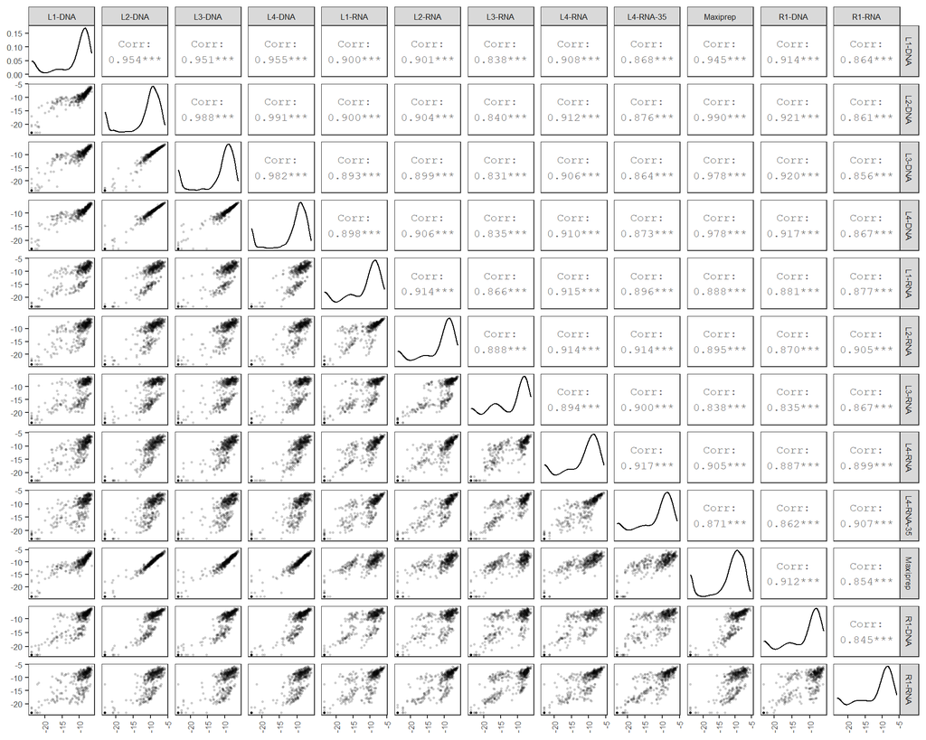

Amplicon log2 proportion correlations between all samples in the analysis. L1-, L2-, L3-, L4-DNA/RNA are the primary experimental samples. L4-RNA-35 is the high PCR cycle control. R1-DNA/RNA are samples collected from the right hemisphere, contralateral to the MPRA library injection.

```r
ggpairs(log2(amp.prop.plot), progress = FALSE,
             lower = list(continuous = wrap("points", size = 0.5, alpha = 0.2, pch = 16),
                          combo = "box", discrete = "blank", na = "na"),
             diag = list(discrete = "blankDiag", continuous = wrap("densityDiag", alpha = 0.4), na = "blankDiag"),
             upper = list(continuous = wrap('cor', size = 3))) +
  theme_bw()+
  theme(panel.grid.major = element_blank(), panel.grid.minor = element_blank(), text = element_text(size = 8), axis.text.x = element_text(angle = 90, hjust = 1, vjust = 0.5))
```

### 2.1.2 DNA vs Maxiprep

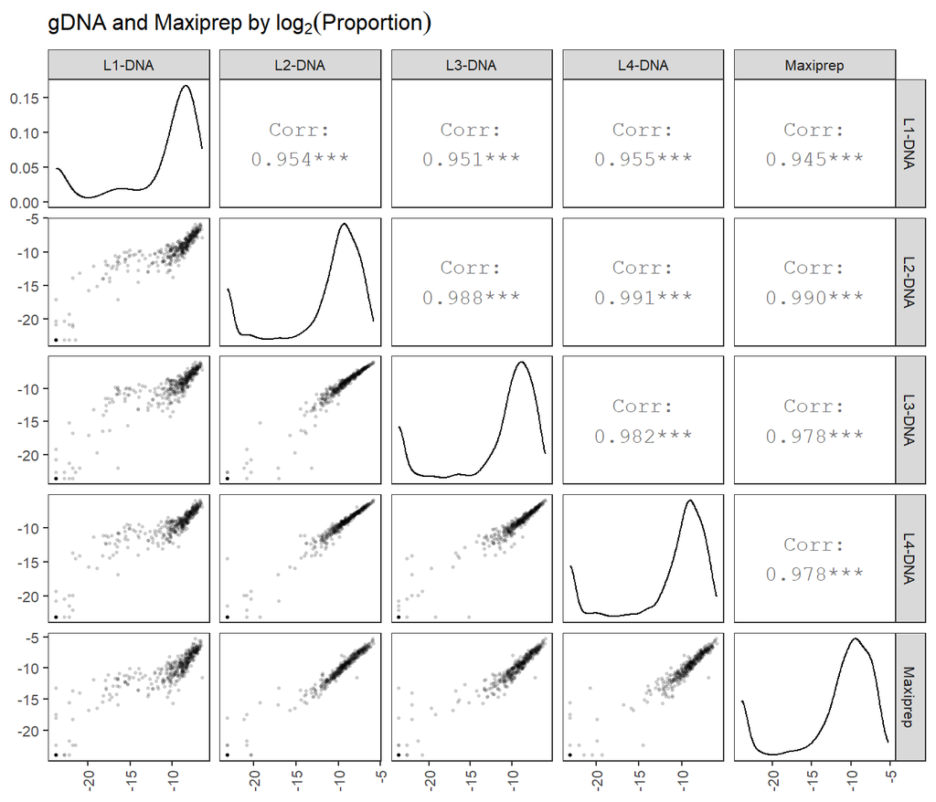

Plasmid Maxiprep library is well correlated with DNA samples, indicating good viral recovery rate after MPRA library injection.

```r
ggpairs(log2(amp.prop.plot[,c(1:4,10)]), progress = FALSE,
             lower = list(continuous = wrap("points", size = 0.5, alpha = 0.2, pch = 16),
                          combo = "box", discrete = "blank", na = "na"),
             diag = list(discrete = "blankDiag", continuous = wrap("densityDiag", alpha = 0.4), na = "blankDiag"),
             upper = list(continuous = wrap('cor', size = 4))) +
  labs(title = bquote(gDNA~and~Maxiprep~by~log[2](Proportion))) +
  theme_bw()+
  theme(panel.grid.major = element_blank(), panel.grid.minor = element_blank(), text = element_text(size = 10),
        axis.text.x = element_text(angle = 90, hjust = 1, vjust = 0.5))
```

### 2.1.3 RNA

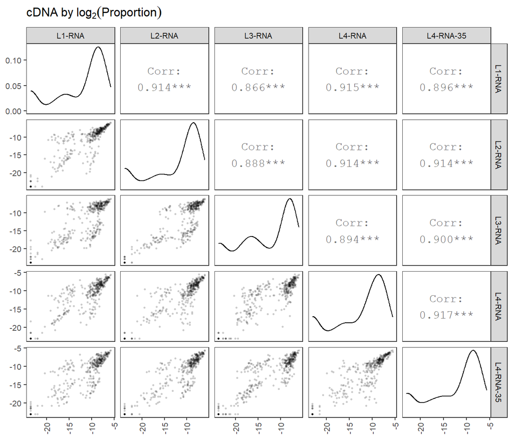

RNA samples are well correlated with each other.

```r
ggpairs(log2(amp.prop.plot[,c(5:9)]), progress = FALSE,
             lower = list(continuous = wrap("points", size = 0.5, alpha = 0.2, pch = 16), combo = "box", discrete = "blank", na = "na"),
             diag = list(discrete = "blankDiag", continuous = wrap("densityDiag", alpha = 0.4), na = "blankDiag"),
             upper = list(continuous = wrap('cor', size = 4))) +
  labs(title = bquote(cDNA~by~log[2](Proportion))) +
  theme_bw()+
  theme(panel.grid.major = element_blank(), panel.grid.minor = element_blank(), text = element_text(size = 10), axis.text.x = element_text(angle = 90, hjust = 1, vjust = 0.5))
```

# 3. Quality control

## 3.1 Presence of other libraries

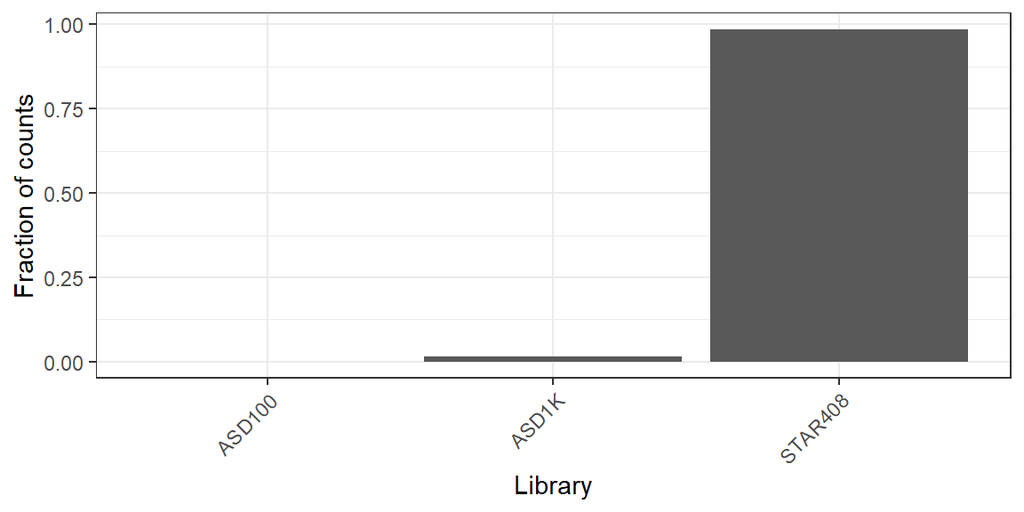

The vast majority of library counts belong to the STAR408 library. There is no appreciable amount of unexpected and undesired amplicons in our DNA libraries

```r
# I'm testing the composition in the 4 main gDNA samples only, ignoring minor differences in library depths.

df_gDNA <- amp_counts[,c(4,6:9,17, 18)]
df_gDNA_m <- melt(df_gDNA)

DT <- data.table(df_gDNA_m)

# Bar plot per library type
lib_composition <- DT[,list(Sum=sum(value)), by=c("Color")]
lib_composition$Fraction <- lib_composition$Sum / sum(lib_composition$Sum)


  ggplot(lib_composition, aes(x = Color, y = Fraction))+
  geom_bar(stat="identity") +
  theme_bw() + theme(axis.text.x = element_text(angle = 45, hjust = 1, vjust = 1)) +
  labs(x="Library", y="Fraction of counts")
```

```r
 knitr::kable(lib_composition)
```

| Color | Sum | Fraction |
| --- | --- | --- |
| STAR408 | 45658994 | 0.9857989 |
| ASD100 | 26 | 0.0000006 |
| ASD1K | 657721 | 0.0142005 |

## 3.2 STAR408 subcategories

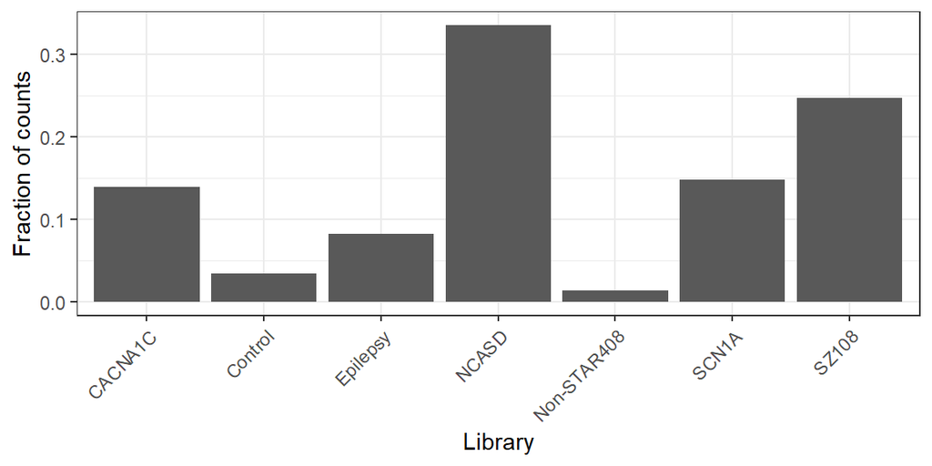

```r
# Bar plot per STAR408 amplicon class
lib_composition <- DT[,list(Sum=sum(value)), by=c("Color2")]
lib_composition$Fraction <- lib_composition$Sum / sum(lib_composition$Sum)

  ggplot(lib_composition, aes(x = Color2, y = Fraction))+
  geom_bar(stat="identity")+
  theme_bw() + theme(axis.text.x = element_text(angle = 45, hjust = 1, vjust = 1)) +
  labs(x="Library", y="Fraction of counts")
```

```r
knitr::kable(table(amp_counts$Color2), caption = "Number of amplicons divided by STAR408 amplicon subcategories")
```

Number of amplicons divided by STAR408 amplicon subcategories

| Var1 | Freq |
| --- | --- |
| CACNA1C | 22 |
| Control | 16 |
| Epilepsy | 29 |
| NCASD | 129 |
| Non-STAR408 | 2099 |
| SCN1A | 70 |
| SZ108 | 142 |

```r
## 3.3 Sum of counts per library type
# Count summary of major gDNA and cDNA samples per library.

df_major <- amp_counts[,c(4, 6:9, 12,13, 14, 11, 17, 18)]
df_major_m <- melt(df_major)

DT <- data.table(df_major_m)

# Bar plot per library type
sum_of_counts <- DT[,list(Sum=sum(value)), by=c("Color", "variable")]
```

# 4. Ratiometric activity

```r
# Calculation of the ratiometric activity

L1_act <- amp.prop.plot$`L1-RNA` / amp.prop.plot$`L1-DNA`
L2_act <- amp.prop.plot$`L2-RNA` / amp.prop.plot$`L2-DNA`
L3_act <- amp.prop.plot$`L3-RNA` / amp.prop.plot$`L3-DNA`
L4_act <- amp.prop.plot$`L4-RNA` / amp.prop.plot$`L4-DNA`
L4H_act <- amp.prop.plot$`L4-RNA-35` / amp.prop.plot$`L4-DNA`
R1_act <- amp.prop.plot$`R1-RNA` / amp.prop.plot$`R1-DNA`

amp.act <- data.frame("amp_id" = rownames(amp.prop.plot),
                      "L1_Activity" = L1_act,
                      "L2_Activity" = L2_act,
                      "L3_Activity" = L3_act,
                      "L4_Activity" = L4_act,
                      "L4-35_Activity" = L4H_act,
                      "R1_Activity" = R1_act)

amp.act <- merge(amp.act, amp_counts[, c(4,17:18)], by.x = "amp_id", by.y = "Amp_name")
```

## 4.1 Activity correlation plots

### 4.1.1 Individual samples

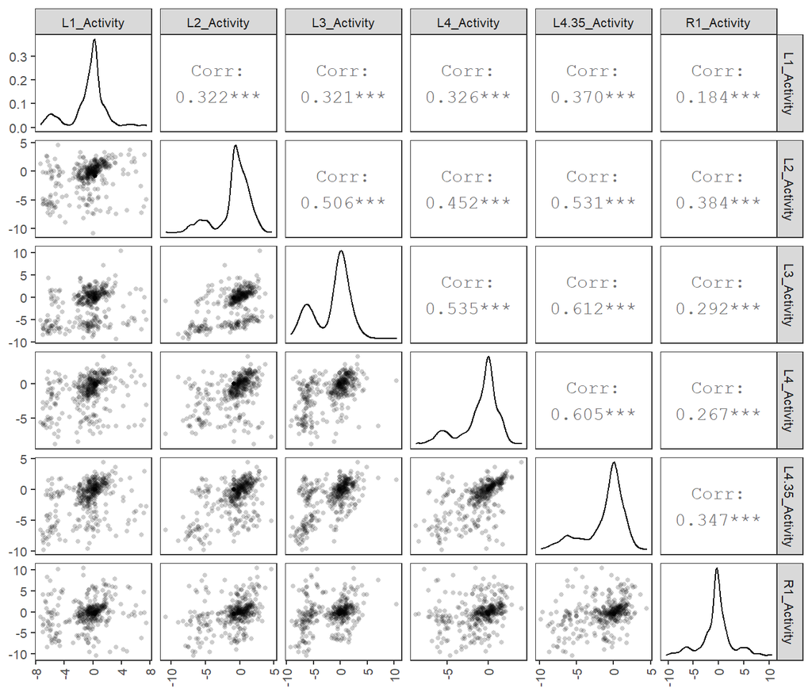

```r
amp.act_plot <- amp.act
rownames(amp.act_plot) <- amp.act_plot$amp_id
amp.act_plot <- amp.act_plot[,2:7]

ggpairs(log2(amp.act_plot), progress = FALSE,
             lower = list(continuous = wrap("points", size = 1, alpha = 0.2, pch = 16),
                          combo = "box", discrete = "blank", na = "na"),
             diag = list(discrete = "blankDiag", continuous = wrap("densityDiag", alpha = 0.4), na = "blankDiag"),
             upper = list(continuous = wrap('cor', size = 4)))+
        theme_bw()+
        theme(panel.grid.major = element_blank(), panel.grid.minor = element_blank(),
              text = element_text(size = 10),
              axis.text.x = element_text(angle = 90, hjust = 1, vjust = 0.5))
```

### 4.1.2 Mean activity correlations

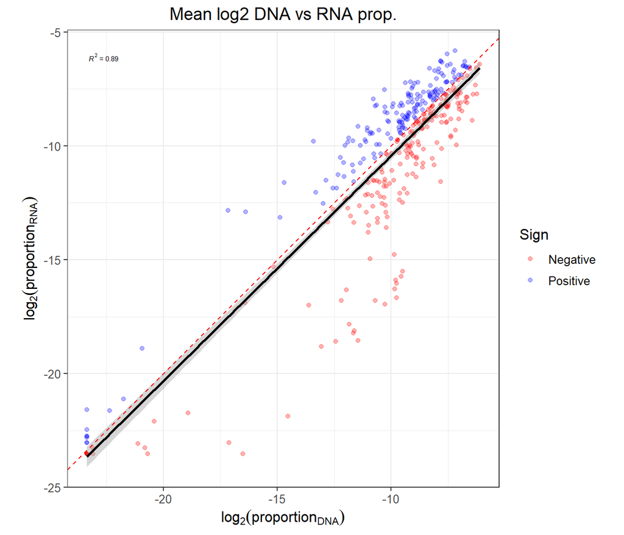

DNA vs RNA proportions suggest good linear correlation

```r
library(genefilter)
library(ggpmisc)

# Calculating average activity and annotating amplicon types. I'm only using the 4 major replicates for calculating the means, skipping the 35 cycle PCR control (replicate), and the contralateral ("R", right hemisphere) sample.


amp.prop.plot$DNA_prop_mean <- rowMeans(as.matrix(amp.prop.plot[,1:4]))
amp.prop.plot$DNA_prop_SD <- rowSds(as.matrix(amp.prop.plot[,1:4]))

amp.prop.plot$RNA_prop_mean <- rowMeans(as.matrix(amp.prop.plot[,5:8]))
amp.prop.plot$RNA_prop_SD <- rowSds(as.matrix(amp.prop.plot[,5:8]))

# This is to indicate amplicons with RNA_prop_mean > DNA_prop_mean
amp.prop.plot$Sign <- ifelse(amp.prop.plot$RNA_prop_mean / amp.prop.plot$DNA_prop_mean > 1, "Positive", "Negative")

formula <- y ~ x

ggplot(amp.prop.plot, aes(x = log2(DNA_prop_mean), y = log2(RNA_prop_mean)))+
  geom_point(alpha = 0.3, aes(color = Sign))+
  scale_color_manual(values = c("red", "blue")) +
  labs(title = "Mean log2 DNA vs RNA prop.", x = bquote(log[2](proportion[DNA])), y = bquote(log[2](proportion[RNA])))+
  geom_abline(intercept = 0, color = "red", linetype = 2)+
  geom_smooth(formula = formula, method = 'lm', color = "black")+
  stat_poly_eq(formula = formula, parse = TRUE, size = 2)+
  geom_abline(intercept = 0, color = "red", linetype = 2)+
  coord_fixed()+
  theme_bw()+
  theme(text = element_text(size = 12), plot.title = element_text(size = 14))+
  theme(plot.title = element_text(hjust = 0.5))
```

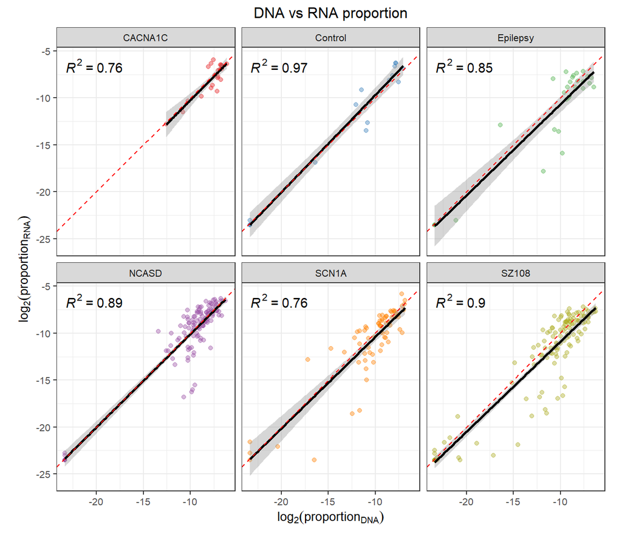

STAR408 amplicons split into subcategories

```r
# Adding Colors indicating library type from amp_counts
amp.prop.plot$Amp_name <- rownames(amp.prop.plot)
amp.prop.plot <- merge(amp.prop.plot, amp_counts[,c(4,17,18)], by = "Amp_name")

j_brew_colors <- brewer.pal(n = 8, name = "Set1")[c(1:6)]
j_brew_colors <- c("#E41A1C", "#377EB8", "#4DAF4A", "#984EA3","#FF7F00", "#abab20")

ggplot(amp.prop.plot, aes(x = log2(DNA_prop_mean), y = log2(RNA_prop_mean)))+
  geom_point(alpha = 0.4, aes(color = Color2))+
  labs(title = "DNA vs RNA proportion",
       x = bquote(log[2](proportion[DNA])),
       y = bquote(log[2](proportion[RNA])),
       color = NULL)+
  geom_abline(intercept = 0, color = "red", linetype = 2)+
  geom_smooth(formula = formula, method = 'lm', color = "black")+
  stat_poly_eq(formula = formula, parse = TRUE)+
  geom_abline(intercept = 0, color = "red", linetype = 2)+
  coord_fixed() +
  theme_bw()+
  theme(plot.title = element_text(hjust = 0.5), text = element_text(size = 10), legend.position = "none")+
  scale_color_manual(values = j_brew_colors)+
  facet_wrap(~ Color2)
```

### 4.1.2 Mean activity barplot

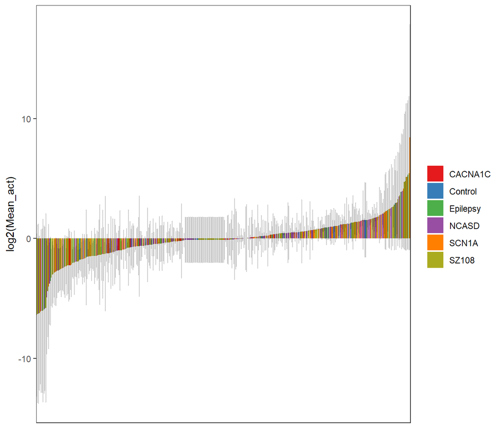

```r
# Calculating average activity and annotating amplicon types. I'm only using the 4
# major replicates for calculating the means, skipping the 35 cycle PCR control, and the contralateral ("R") sample.

amp.act$Mean_act <- rowMeans(as.matrix(amp.act[,c(2:5)]))
amp.act$Mean_act_log2 <- rowMeans(as.matrix(log2(amp.act[,c(2:5)])))
amp.act$SD <- rowSds(as.matrix(amp.act[,c(2:5)]))
amp.act$SD_log2 <- rowSds(as.matrix(log2(amp.act[,c(2:5)])))

amp.act2 <- arrange(amp.act, Mean_act)
amp.act2$amp_id <- factor(amp.act2$amp_id, levels = amp.act2$amp_id)

# log2 Mean activity of all 408 amplicons, color coded by amplicon type
ggplot(amp.act2, aes(x = amp_id, y = log2(Mean_act), fill = Color2))+
  geom_bar(stat="identity")+
  labs(fill = NULL) +
  theme_bw()+
  theme(
    panel.grid.major = element_blank(),
    panel.grid.minor = element_blank(),
    axis.title.x=element_blank(),
    axis.text.x=element_blank(),
    axis.ticks.x=element_blank())+
  scale_fill_manual(values = j_brew_colors)+
  geom_errorbar(aes(ymin = log2(Mean_act) - log2(SD), ymax = log2(Mean_act) + log2(SD)), width = 0.1, alpha = 0.2)
```

```r
# This builds a summary data frame containing counts, proportions, activity, and average values.

##### Counts #####
amp_counts_df <- dplyr::filter(amp_counts, Color == "STAR408")
amp_counts_df <- amp_counts_df[,c(4, 1:3, 17, 18, 6:9, 12:14, 11)]
colnames(amp_counts_df) <- c(colnames(amp_counts_df)[1:6], "L1_DNA_count", "L2_DNA_count", "L3_DNA_count", "L4_DNA_count",
                             "L1_RNA_count", "L2_RNA_count", "L3_RNA_count", "L4_RNA_count")

amp_counts_df$DNA_count_mean <- rowMeans(as.matrix(amp_counts_df[,7:10]))
amp_counts_df$DNA_count_SD <- rowSds(as.matrix(amp_counts_df[,7:10]))

amp_counts_df$RNA_count_mean <- rowMeans(as.matrix(amp_counts_df[,11:14]))
amp_counts_df$RNA_count_SD <- rowSds(as.matrix(amp_counts_df[,11:14]))

# Testing for > 200 counts in 4 DNA samples. DNA threshold.
min_count = 200
amp_counts_df$Pass_DNA_count <- rowSums(amp_counts_df[,c(7:10)]>min_count) >=4

##### Proportions #####
amp.prop.plot_df <- amp.prop.plot[,c(1:9, 14:18)]
# Sanity check:
data.frame("one" = colnames(amp.prop.plot_df),
           "two" = c("Amp_name", "L1_DNA_prop", "L2_DNA_prop", "L3_DNA_prop", "L4_DNA_prop",
                     "L1_RNA_prop", "L2_RNA_prop", "L3_RNA_prop", "L4_RNA_prop",
                     "DNA_prop_mean", "DNA_prop_SD", "RNA_prop_mean", "RNA_prop_SD", "Sign"))
```

```
##              one           two
## 1       Amp_name      Amp_name
## 2         L1-DNA   L1_DNA_prop
## 3         L2-DNA   L2_DNA_prop
## 4         L3-DNA   L3_DNA_prop
## 5         L4-DNA   L4_DNA_prop
## 6         L1-RNA   L1_RNA_prop
## 7         L2-RNA   L2_RNA_prop
## 8         L3-RNA   L3_RNA_prop
## 9         L4-RNA   L4_RNA_prop
## 10 DNA_prop_mean DNA_prop_mean
## 11   DNA_prop_SD   DNA_prop_SD
## 12 RNA_prop_mean RNA_prop_mean
## 13   RNA_prop_SD   RNA_prop_SD
## 14          Sign          Sign
```

```r
colnames(amp.prop.plot_df) <- c("Amp_name", "L1_DNA_prop", "L2_DNA_prop", "L3_DNA_prop", "L4_DNA_prop",
                               "L1_RNA_prop", "L2_RNA_prop", "L3_RNA_prop", "L4_RNA_prop",
                               "DNA_prop_mean", "DNA_prop_SD", "RNA_prop_mean", "RNA_prop_SD", "Sign")




##### Activity #####
amp.act_df <- amp.act_plot
amp.act_df$Amp_name <- rownames(amp.act_df)
rownames(amp.act_df) <- NULL
amp.act_df <- amp.act_df[,c(7, 1:4)]

amp.act_df$Mean_act <- rowMeans(as.matrix(amp.act_df[,c(2:5)]))
amp.act_df$Mean_act_SD <- rowSds(as.matrix(amp.act_df[,c(2:5)]))


x <- merge(amp_counts_df, amp.prop.plot_df, by = "Amp_name")
y <- merge(x, amp.act_df, by = "Amp_name")

#Adding Maxi prep stats
y <- merge(x, amp.act_df, by = "Amp_name")

Maxi_counts <- dplyr::filter(amp_counts, Color == "STAR408")[,c(4, 10)]
colnames(Maxi_counts) <- c("Amp_name", "Maxi_counts")

Maxi_prop <- amp.prop[,c(13, 6)]
rownames(Maxi_prop) <- NULL
colnames(Maxi_prop) <- c("Amp_name", "Maxi_prop")

Maxi <- merge(Maxi_counts, Maxi_prop)

y <- merge(y, Maxi, by = "Amp_name")

# Comparing to the previous version of this script this CSV has "L4.35_Activity" "R1_Activity" now.
#write.csv(file = "./CSV_output_files/STAR408_counts_proportions_activity.csv", y)
```

# 5 GC content

Explored with 322 amplicons passing > 200 counts in 4 DNA samples

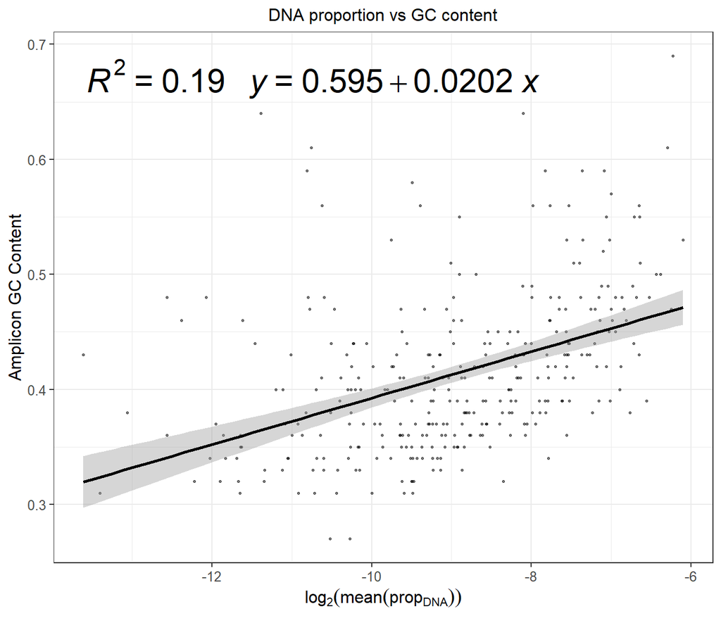

GC content is positively corelated with DNA abundance suggesting that GC content is a predictor or a confounder of the activity.

```r
# KC: I think Yurong calculated these values. I later checked they match values from in-silico PCR.
GC_content <- read.table("./STAR408_Amplicons_GC.txt", header = TRUE)

# Adding GC column to the cleaned and full (y) dfs
y <- merge(y, GC_content, by.x = "Amp_name", by.y = "Amplicon")

df_clean <- dplyr::filter(y, Pass_DNA_count == TRUE) # 322 rows

# Lets see how GC content correlates with activity and abundance.
formula <- y ~ x

ggplot(df_clean, aes(x = log2(DNA_prop_mean), y = GC))+
  geom_point(size = 0.5, alpha = 0.5)+
  geom_smooth(formula = formula, method = 'lm', color = "black")+
  #stat_poly_eq(formula = formula, parse = TRUE, eq.with.lhs = TRUE)+
  stat_poly_eq(formula = formula,
               aes(label = paste(..rr.label.., ..eq.label.., sep = "~~~")),
               parse = TRUE, size = 8)+
  labs(title = "DNA proportion vs GC content",
       x = bquote(log[2](mean(prop[DNA]))),
       y = "Amplicon GC Content")+
  theme_bw()+
  theme(text = element_text(size = 12), plot.title = element_text(size = 12))+
  theme(plot.title = element_text(hjust = 0.5))+
  theme(plot.title = element_text(hjust = 0.5))
```

```r
## Conclusions
# GC content is positively corelated with gDNA abundance suggesting that GC content is a good predictor or a confounder of the activity modeling.
```

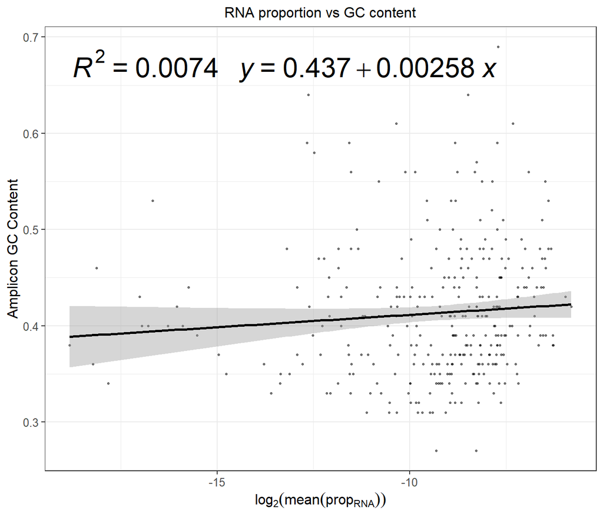

Interestingly RNA abundance does not demonstrate this positive correlation

```r
ggplot(df_clean, aes(x = log2(RNA_prop_mean), y = GC))+
  geom_point(size = 0.5, alpha = 0.5) +
  geom_smooth(formula = formula, method = 'lm', color = "black")+
  #stat_poly_eq(formula = formula, parse = TRUE, eq.with.lhs = TRUE)+
  stat_poly_eq(formula = formula,
               aes(label = paste(..rr.label.., ..eq.label.., sep = "~~~")),
               parse = TRUE, size = 8) +
  labs(title = "RNA proportion vs GC content", x = bquote(log[2](mean(prop[RNA]))), y = "Amplicon GC Content") +
  theme_bw()+
  theme(text = element_text(size = 12), plot.title = element_text(size = 12))+
  theme(plot.title = element_text(hjust = 0.5))
```

```r
# Interestingly RNA abundance does not demonstrate this positive correlation
```

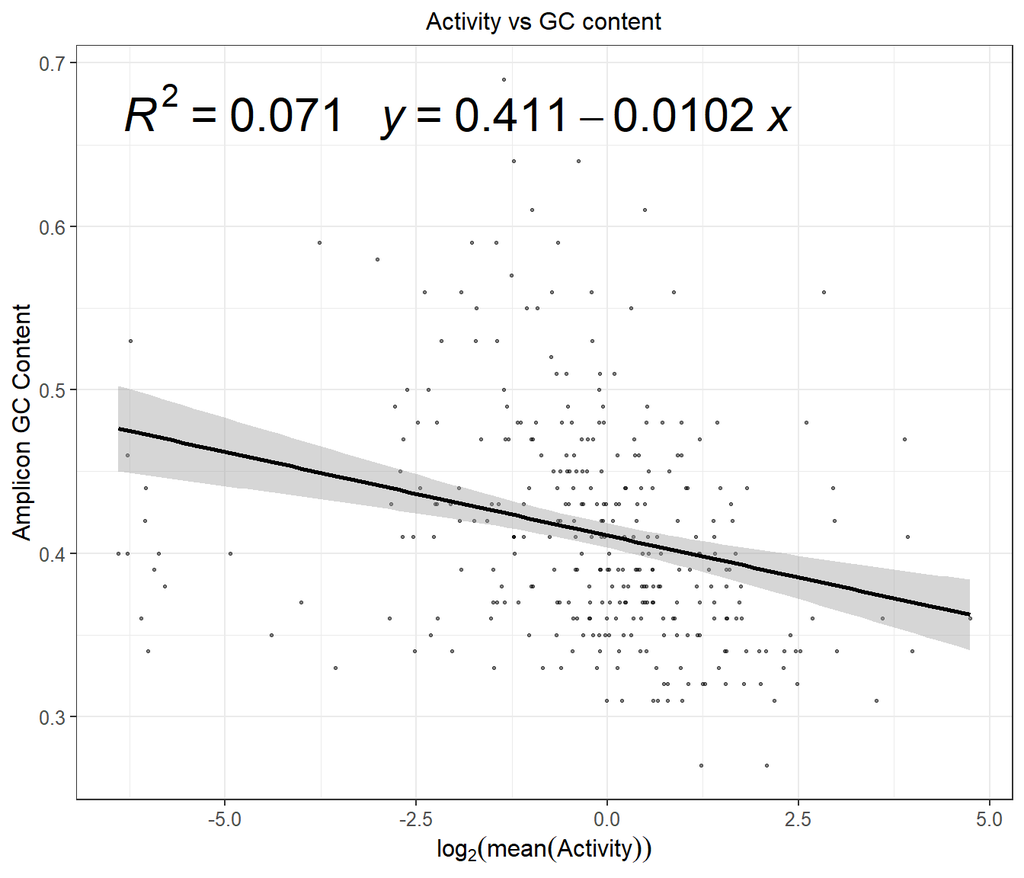

Activity is negatively correlated with GC content

```r
ggplot(df_clean, aes(x = log2(Mean_act), y = GC))+
  geom_point(size = 0.5, alpha = 0.5) +
  geom_smooth(formula = formula, method = 'lm', color = "black")+
  #stat_poly_eq(formula = formula, parse = TRUE, eq.with.lhs = TRUE)+
  stat_poly_eq(formula = formula,
               aes(label = paste(..rr.label.., ..eq.label.., sep = "~~~")),
               parse = TRUE, size = 8) +
  labs(title = "Activity vs GC content", x = bquote(log[2](mean(Activity))), y = "Amplicon GC Content") +
  theme_bw()+
  theme(text = element_text(size = 12), plot.title = element_text(size = 12))+
  theme(plot.title = element_text(hjust = 0.5))
```

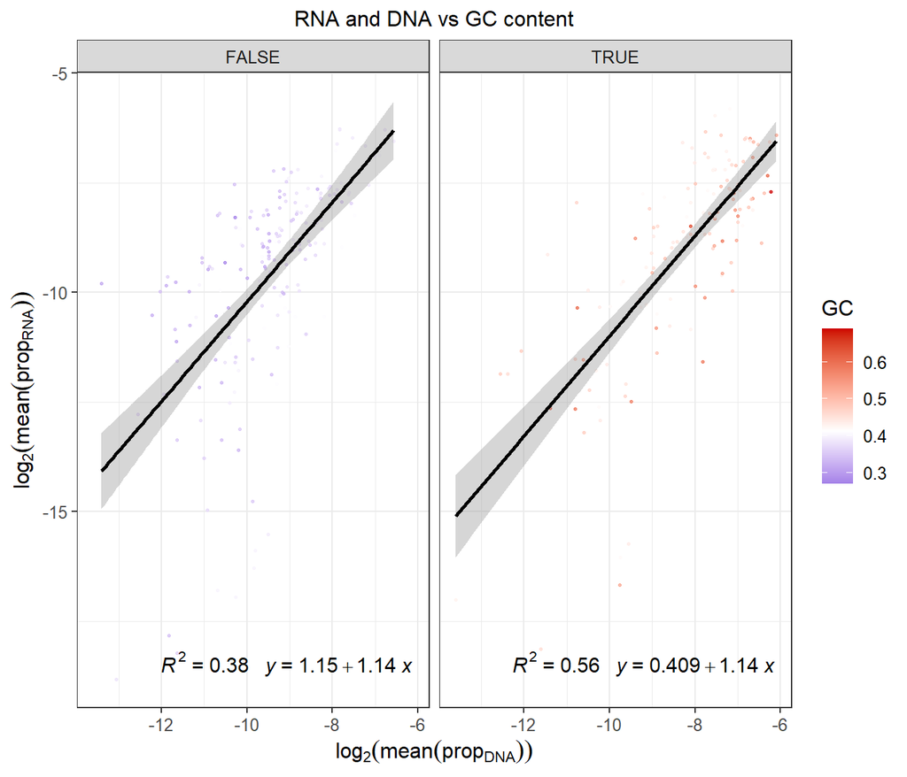

```r
# Color code the GC content in the gDNA vs cDNA prop plot.
# Split at GC = 0.5
y$GC_above_mean <- ifelse(y$GC > mean(y$GC), "TRUE", "FALSE")
df_clean <- dplyr::filter(y, Pass_DNA_count == TRUE)

# Split at mean GC = 0.4063235 <--- 0.4165686?
ggplot(df_clean, aes(x = log2(DNA_prop_mean), y = log2(RNA_prop_mean), color = GC))+
  geom_point(size = 0.5, alpha = 0.75)+
  geom_smooth(formula = formula, method = 'lm', color = "black")+
  stat_poly_eq(formula = formula, label.y = "bottom", label.x = "right",
               aes(label = paste(..rr.label.., ..eq.label.., sep = "~~~")),
               parse = TRUE, size = 4)+
  scale_color_gradient2(midpoint = mean(df_clean$GC), low="blue3", mid="white",
                        high="red3", space ="Lab" )+
  labs(title = "RNA and DNA vs GC content",
       x = bquote(log[2](mean(prop[DNA]))),
       y = bquote(log[2](mean(prop[RNA]))))+
  theme_bw()+
  theme(text = element_text(size = 12), plot.title = element_text(size = 12))+
  facet_wrap(~ GC_above_mean)+
  theme(plot.title = element_text(hjust = 0.5))
```

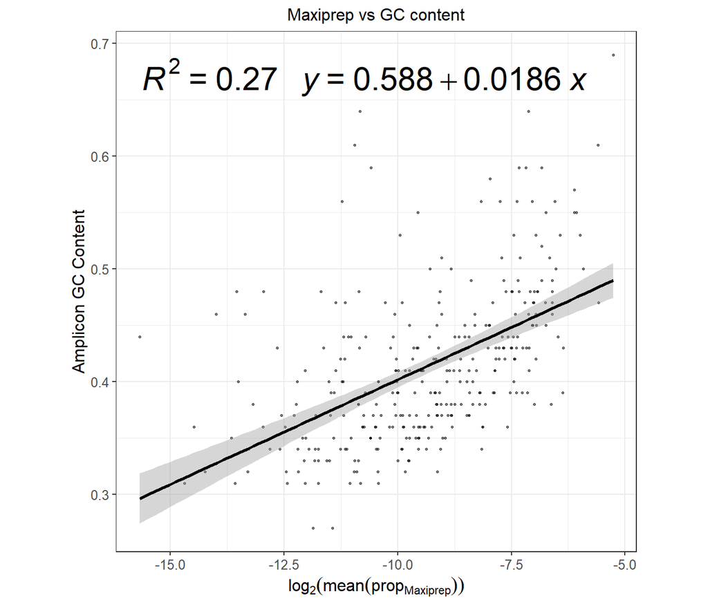

Mean gDNA proportions are almost the same as Maxiprep proportions. This suggests that the library prep process favors amplicons with higher GC content.

```r
## Lets see how this corelation looks for the Maxiprep proportions. This should differentiate if this increased aboundance of high GC amplicons in gDNA is due to PCR or amplicon stability, I bet it's the latter, because PCR should favour high AT amplification.

# Mean gDNA proportions are almost the same as Maxiprep proportions.
# This suggests that the library prep process favors amplicons with higher GC content.

ggplot(df_clean, aes(x = log2(Maxi_prop), y = GC))+
  geom_point(size = 0.5, alpha = 0.5)+
  geom_smooth(formula = formula, method = 'lm', color = "black")+
  stat_poly_eq(formula = formula, label.y = "top", label.x = "left",
               aes(label = paste(..rr.label.., ..eq.label.., sep = "~~~")),
               parse = TRUE, size = 8)+
  scale_color_gradient2(midpoint = mean(df_clean$GC), low="blue3", mid="white",
                        high="red3", space ="Lab" )+
  labs(title = "Maxiprep vs GC content", x = bquote(log[2](mean(prop[Maxiprep]))), y = "Amplicon GC Content") +
  theme_bw()+
  theme(text = element_text(size = 12), plot.title = element_text(size = 12), aspect.ratio = 1)+
  theme(plot.title = element_text(hjust = 0.5))
```

# 6 In silico PCR

- **Objectives**
  - Reassess amplicon amplification specificity
  - Report amplicon coordinates in GRCh38
  - Independently verify GC content data

```r
# Integration with In silico PCR analysis

# In silico PCR results are located at "G:\Shared drives\Nord Lab Team Drive\Projects\MPRA_ComputationalAnalysis\STAR408_ComputationalAnalysis\STAR408_KC\In_silico_PCR_STAR408"

# These primers and products were designed on hg19 genome.
primers <- read.csv("In_silico_PCR_STAR408/STAR408_primers.csv", header = TRUE, fill = TRUE)

# In silico PCR was run in batches:

a <- read.csv("In_silico_PCR_STAR408/STAR408_in_silico_PCR__1_to_10.csv", header = TRUE)
b <- read.csv("In_silico_PCR_STAR408/STAR408_in_silico_PCR__11_to_100.csv", header = TRUE)
c <- read.csv("In_silico_PCR_STAR408/STAR408_in_silico_PCR__101_to_120.csv", header = TRUE)
d <- read.csv("In_silico_PCR_STAR408/STAR408_in_silico_PCR__121_to_200.csv", header = TRUE)
e <- read.csv("In_silico_PCR_STAR408/STAR408_in_silico_PCR__201_to_250.csv", header = TRUE)
f <- read.csv("In_silico_PCR_STAR408/STAR408_in_silico_PCR__251_to_300.csv", header = TRUE)
g <- read.csv("In_silico_PCR_STAR408/STAR408_in_silico_PCR__301_to_350.csv", header = TRUE)
h <- read.csv("In_silico_PCR_STAR408/STAR408_in_silico_PCR__351_to_400.csv", header = TRUE)
i <- read.csv("In_silico_PCR_STAR408/STAR408_in_silico_PCR__401_to_408.csv", header = TRUE)

df_in_silico <- rbind(a, b, c, d, e, f, g ,h, i)
df_in_silico$X <- NULL
df_in_silico$CHROMOSOME <- NULL

colnames(df_in_silico)[13] <- "Chr_GRCh38_pred"
colnames(df_in_silico)[14] <- "Amplicon_Start_GRCh38"
colnames(df_in_silico)[15] <- "Amplicon_End_GRCh38"
colnames(df_in_silico)[16] <- "Amplicon_length_GRCh38"
colnames(df_in_silico)[18] <- "Sequence_GRCh38"

#head(df_in_silico[,1:17])
#dim(df_in_silico)  # 479 PCR products vs 408 amplicons or primer pairs.

## Linda modification: fix weird column factor issues
## e.g.
# > levels(df_in_silico$Multiple.Amplicons.)
# [1] "No"   "Yes"  "No  " ## in addition to chr and other columns
# KC: thanks!
colnames(df_in_silico)[8] <- "Multiple.Amplicons"
df_in_silico$Multiple.Amplicons <- trimws(df_in_silico$Multiple.Amplicons)
df_in_silico$chr <- trimws(df_in_silico$chr)

# Flag amplicons with multiple PCR products
# There are 8 unspecific amplicons in In silico PCR with max product size maxProductSize = 1500 bp.
# Most by products have much shorter lengths, making them likely to be packaged into viruses. The lack of PCR specificity decreases its efficiency.

df <- as.data.frame(table(df_in_silico$UNIQID))
unspecific_PCR <- dplyr::filter(df, Freq > 1)

# Unspecific amplicons and their product sizes
#dplyr::filter(df_in_silico, UNIQID %in% unspecific_PCR$Var1)[,c(1,16)]

# In_silico_specificity = In silico PCR predicted multiple products.
y$Perfect_In_silico_specificity <- ifelse(y$Amp_name %in% as.character(unspecific_PCR$Var1), FALSE, TRUE)

# Sanity check
#filter(y, Perfect_In_silico_specificity == FALSE)

# GC content calculation
library(stringr)

GC_cont <- function(x){

  x <- toupper(x) # just in case
  num_g <- str_count(x, "G")
  num_c <- str_count(x, "C")
  gc_content <- (num_g + num_c) / str_length(x)
  gc_content

}

df_in_silico$GC2 <- GC_cont(df_in_silico$Sequence)

# I'm flagging amplicons as intended if:
# 1) chromosomes predicted by isPCR and chromosomes expected from primer design match,
# 2) isPCR product length is +/- 5 bp from the product predicted during primer design on hg19 genome.

# Fixing X chrom name and chrom class encoding to permit logical operations
# an ugly hack...
df_in_silico$chr <- ifelse(is.na(as.numeric(df_in_silico$chr)), 23, as.numeric(df_in_silico$chr))
df_in_silico$Chr_GRCh38_pred <- as.numeric(df_in_silico$Chr_GRCh38_pred)
df_in_silico$chr <- as.numeric(df_in_silico$chr)

# NA due to a lack of 1 isPCR product was messing up with the analysis - removes 1 record.
d <- na.omit(df_in_silico)

# Sanity checks
#unique(setdiff(df_in_silico$UNIQID, d$UNIQID))
#dplyr::filter(df_in_silico, UNIQID %in% unique(setdiff(df_in_silico$UNIQID, d$UNIQID)))
#

d$Intended_interval <- sapply(1:nrow(d), function(x) d$Amplicon.Length[x]
                              %in% c((d$Amplicon_length_GRCh38[x] - 5) : (d$Amplicon_length_GRCh38[x] + 5)))

# Offending amplicon with no PCR product
#setdiff(df_in_silico$UNIQID, d$UNIQID)   #  "274_SZ108"

# Extracting that extra amplicon which fail to amplify in in silico PCR
am274 <- dplyr::filter(df_in_silico, UNIQID == "274_SZ108")
am274$Intended_interval <- NA

d2 <- rbind(d, am274)  # Adding this failed amplicon to the full dataset

# Checks if the chrom number is as expected
d2$Intended_chr <- d2$chr == d2$Chr_GRCh38_pred

d2$Intended_amplicon <- d2$Intended_chr & d2$Intended_interval

#sum(na.omit(d2$Intended_amplicon))  # 406 amplicons meeting Intended amplicon criteria

# Manual inspection
#dim(dplyr::filter(d2,  Intended_amplicon == FALSE)) # 72 spurious amplicons
PCR_byproducts <- dplyr::filter(d2,  Intended_amplicon == FALSE) # 71 PCR byproducts
#PCR_byproducts[,c(1, 6, 16, 20, 12, 13, 21:22)]

# Are they the same UNIQIDs as previously identified multi-product IDs?  YES.
# There is no need to update y
#unique(PCR_byproducts$UNIQID)  #9 + "274_SZ108"

# Manual check if these non specific amplicons have at least 1 specific/intended product
# dplyr::filter(d2, UNIQID %in% as.character(unique(PCR_byproducts$UNIQID)))[,c(1, 6, 16, 20, 12, 13, 21:22)]

# 16_CACNA1C - 1 specific amplicon
# 51_SCN1A   - 1 specific amplicon
# 99_SCN1A   - 1 specific amplicon
# 132_NCASD  - 1 specific amplicon
# 220_NCASD  - 1 specific amplicon
# 277_SZ108  - 1 amplicon 7 bp shorter than expected
# 289_SZ108  - 1 specific amplicon
# 290_SZ108  - 1 specific amplicon
# 355_SZ108  - 1 specific amplicon

# Marking amplicons with at least 1 specific PCR product
x <- unique(dplyr::filter(d2, Intended_amplicon == TRUE)$UNIQID)

# What a mess! There are differences in amplicon names :/
#setdiff(d2$UNIQID, y$Amp_name)
#setdiff(y$Amp_name, d2$UNIQID)

y$Amp_name2 <- gsub("Control_.*", "Controls", y$Amp_name)

# Good. Now we have the same Amp_name reference
#setdiff(y$Amp_name2, d2$UNIQID) # character(0)
#setdiff(d2$UNIQID, y$Amp_name2) # character(0)

y$At_least_1_specific_in_sil_prod <- ifelse(y$Amp_name2 %in% x, TRUE, FALSE) #406 of 408

# Amplicons without at least 1 specific PCR product
# dplyr::filter(y, At_least_1_specific_in_sil_prod == FALSE)$Amp_name  # 2 amplicons <--- Linda: where is this 2 coming from?
# KC: 274 doesn't have an in-silico PCR product, "277_SZ108" have no PCR product flagged as potentially specific.

# Sanity check = PASSED
# Are all amplicons in y also in the in_silico
#length(unique(primers$Amplicon.ID)) # 408
#length(unique(df_in_silico$UNIQID)) # 408
#length(unique(d$UNIQID)) # 407
#length(unique(d2$UNIQID)) # 408

#dplyr::filter(y, Perfect_In_silico_specificity == FALSE)  # 8 amplicons
#dplyr::filter(y, At_least_1_specific_in_sil_prod == FALSE) # 2 amplicons

# Let's flag amplicons for removal from the training model
d=data.frame(x1=c(-Inf, -Inf), x2=c(+Inf, -15), y1=c(-Inf,-15), y2=c(-15, +Inf))
```

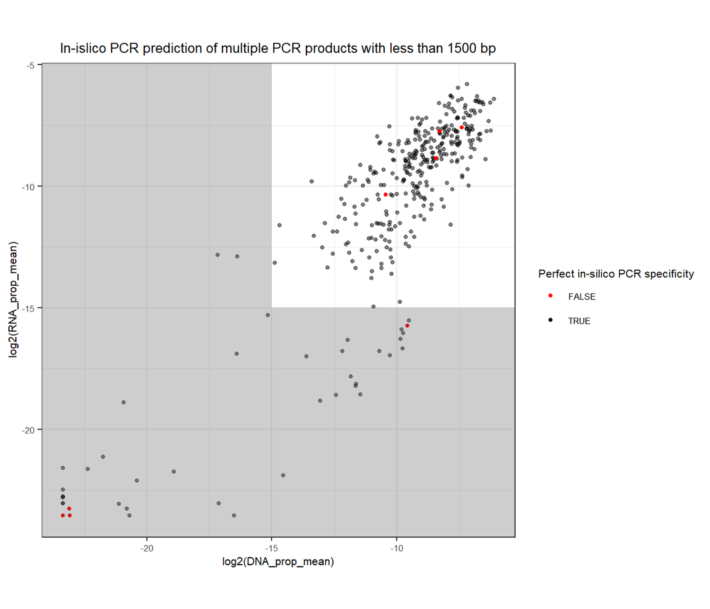

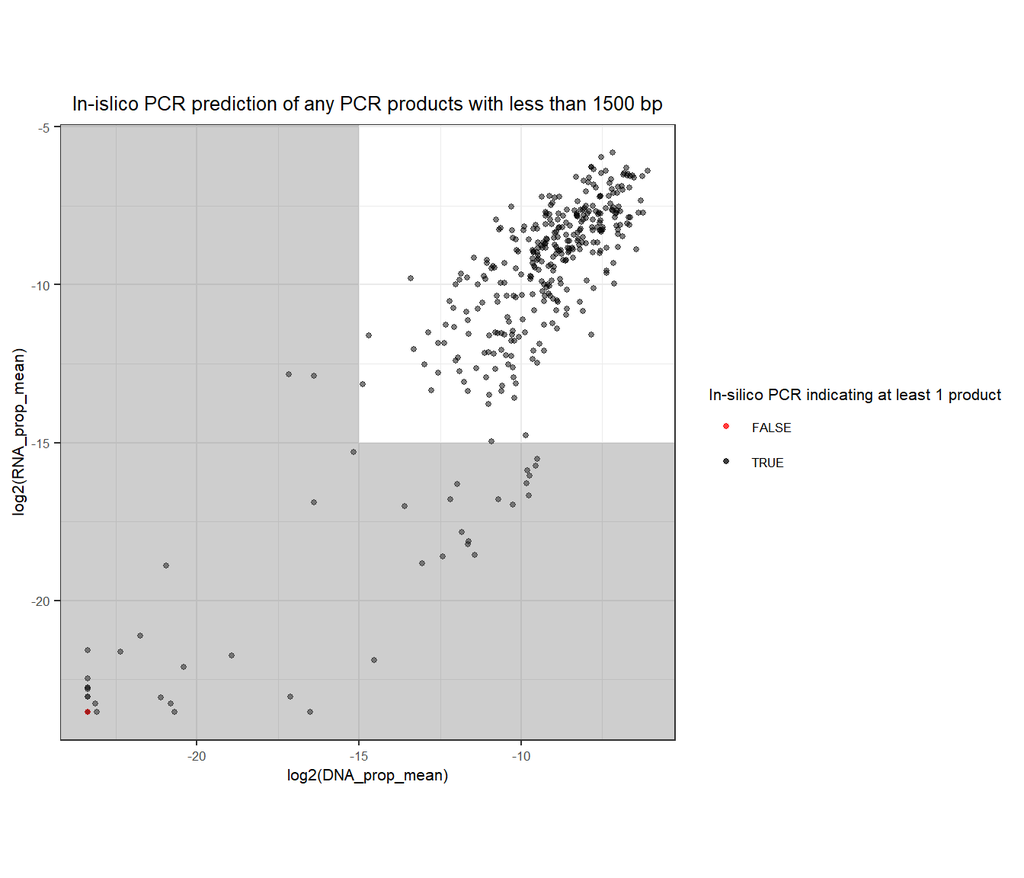

In-silico PCR prodiction of product specificity indicates high accuracy of the initial design. MPRA amplicons with predicted byproducts are not biasing the analysis. Gray area indicates amplicons with low representation removed from MPRA activity modeling.

```r
#
ggplot()+
  geom_point(data = dplyr::filter(y, Perfect_In_silico_specificity == TRUE), size = 1, alpha = 0.5,
             aes(x = log2(DNA_prop_mean), y = log2(RNA_prop_mean), color = Perfect_In_silico_specificity))+
  geom_point(data = dplyr::filter(y, Perfect_In_silico_specificity == FALSE), size = 1, alpha = 1,
             aes(x = log2(DNA_prop_mean), y = log2(RNA_prop_mean), color = Perfect_In_silico_specificity))+
  geom_rect(data=d, mapping=aes(xmin=x1, xmax=x2, ymin=y1, ymax=y2), color = NA, alpha = 0.3)+
  labs(color = "Perfect in-silico PCR specificity",
       title = "In-islico PCR prediction of multiple PCR products with less than 1500 bp")+
  scale_color_manual(values = c("red", "black")) +
  theme_bw() +
  theme(text = element_text(size = 8), aspect.ratio = 1, plot.title = element_text(hjust = 0.5))



# In silico PCR correctly predicts failed products.
ggplot()+
  geom_point(data = dplyr::filter(y, At_least_1_specific_in_sil_prod == TRUE), size = 1, alpha = 0.5,
             aes(x = log2(DNA_prop_mean), y = log2(RNA_prop_mean), color = At_least_1_specific_in_sil_prod))+
  geom_point(data = dplyr::filter(y, At_least_1_specific_in_sil_prod == FALSE), size = 1, alpha = 0.5,
             aes(x = log2(DNA_prop_mean), y = log2(RNA_prop_mean), color = At_least_1_specific_in_sil_prod))+
  scale_color_manual(values = c("red", "black")) +
  geom_rect(data=d, mapping=aes(xmin=x1, xmax=x2, ymin=y1, ymax=y2), color=NA, alpha=0.3)+
  labs(color = "In-silico PCR indicating at least 1 product",
       title = "In-islico PCR prediction of any PCR products with less than 1500 bp")+
  theme_bw()+
  theme(text = element_text(size = 8), aspect.ratio = 1, plot.title = element_text(hjust = 0.5))
```

```r
# Merging isPCR analysis with a bed file

bed$UNIQID <- gsub("Control_.*", "Controls", bed$Amp_name)

df_hg38 <- merge(bed, df_in_silico, by = "UNIQID", all.y = T)

# df_hg38$ChrSub <- df_hg38$Chr_GRCh38_pred - df_hg38$Chr
df_hg38$StartSub <- df_hg38$Amplicon_Start_GRCh38 - df_hg38$Start
df_hg38$EndSub <- df_hg38$Amplicon_End_GRCh38 - df_hg38$End
df_hg38_trunc <- df_hg38[,c("Amp_name", "Chr", "Start", "End",
                            "Amplicon.Length", "Chr_GRCh38_pred",
                            "Amplicon_Start_GRCh38", "Amplicon_End_GRCh38",
                            "Amplicon_length_GRCh38",
                            "StartSub", "EndSub")]

# ISP_FLAG - Matching Start and Stop in bed and isPCR.
# This marks unspecific amplicons by identifying those with Start and End coordinates not matching after  merging a bed file with df_in_silico.
# ISP_FLAG == FALSE - isPCR specific
# ISP_FLAG == TRUE - isPCR unspecific
# sum(na.omit(df_hg38_trunc$ISP_FLAG == FALSE))  # 402 specific amplicons
# sum(na.omit(df_hg38_trunc$ISP_FLAG == TRUE)) # 76 unspecific

df_hg38_trunc$ISP_FLAG <- ifelse(df_hg38_trunc$StartSub == 0 & df_hg38_trunc$EndSub == 0, FALSE, TRUE)


# Add calculated GC values. This is to double check if Yurong's GC content calculation is correct.
# Yes, it is pretty much spot on.
GC_intended_products <- dplyr::filter(d2, Intended_interval == TRUE)[,c(1, 19)]

y_w_2_GC_values <- merge(y, GC_intended_products, by.x = "Amp_name2", by.y = "UNIQID")

# GC and GC2 content is pretty much the same.
#ggplot(y_w_2_GC_values, aes(x = GC, y =  GC2))+
#  geom_point()+
#  geom_abline(intercept = 0, color = "red", linetype = 2)+
#  theme_bw()

lm_GC_Y_vs_C <- lm(GC2 ~ GC, data = y_w_2_GC_values)

y_w_2_GC_values$GC_Y_vs_C_Residuals <- as.numeric(lm_GC_Y_vs_C$residuals)


# head(arrange(y_w_2_GC_values, desc(GC_Y_vs_C_Residuals)))
```

# 7. Linear model

- Do linear model (+/- GC) on only amplicons that pass the following thresholds:
- low RNA proportions removed (-15)
- low DNA proportions removed (-15)
- non-specific in silico PCR removed
- top/bottom 10% cleaned data removed

```r
# make version that has excluded samples (L4-35 and R1)
data.all.incl <- merge(amp.prop.plot, amp.act, by.x = "Amp_name", by.y = "amp_id") # 408 x 32
data.all.incl <- merge(data.all.incl, GC_content, by.x = "Amp_name", by.y = "Amplicon") # 408 x 33

data.all <- y ## y is from's Karol's analysis
data.all$Amp_name <- as.character(data.all$Amp_name)
data.all$Amp_name2 <- as.character(data.all$Amp_name2)
rownames(data.all) <- data.all$Amp_name

## Linda: What is MeanRatio vs MeanRatio_MoM???
## A: MeanRatio = rowMeans(L1-L4 ratiometric activity)
## A: MeanRatio_MoM = rowMeans(amp.prop.plot[,5:8]) / rowMeans(amp.prop.plot[,1:4])

## KC: lm is based on MoM
## Linda: Just to make sure, remake MeanRatio_MoM and MeanRatio with more explicit names
data.all$MeanRatio_MoM <- data.all$RNA_prop_mean / data.all$DNA_prop_mean
data.all$MeanRatio <- rowMeans(data.all[,c("L1_Activity", "L2_Activity", "L3_Activity", "L4_Activity")])
data.all$MeanRatio_sd <- rowSds(data.all[,c("L1_Activity", "L2_Activity", "L3_Activity", "L4_Activity")])
data.all$MSD <- data.all$MeanRatio - data.all$MeanRatio_sd


## Change names to figure groups:
## PutEnh (Control)
## FBDHS (NCASD)
## GWAS (SZ108, Epilepsy)
## LD (SCN1A, CACNA1C)

data.all$Amp_name <- gsub("NCASD", "FBDHS", data.all$Amp_name)
data.all$Amp_name2 <- gsub("NCASD", "FBDHS", data.all$Amp_name2)
data.all$Color2 <- gsub("NCASD", "FBDHS", data.all$Color2)
data.all$Amp_name <- gsub("Epilepsy", "EPIL", data.all$Amp_name)
data.all$Amp_name2 <- gsub("Epilepsy", "EPIL", data.all$Amp_name2)
data.all$Color2 <- gsub("Epilepsy", "EPIL", data.all$Color2)
data.all$Amp_name <- gsub("Control", "PutEnh", data.all$Amp_name)
data.all$Amp_name2 <- gsub("Controls", "PutEnh", data.all$Amp_name2)
data.all$Color2 <- gsub("Control", "PutEnh", data.all$Color2)
data.all$Amp_name <- gsub("SZ108", "SCZ", data.all$Amp_name)
data.all$Amp_name2 <- gsub("SZ108", "SCZ", data.all$Amp_name2)
data.all$Color2 <- gsub("SZ108", "SCZ", data.all$Color2)

data.all$Amp_Full_Name <- data.all$Amp_name
data.all$Amp_name <- gsub("EPIL|SCZ", "GWAS", data.all$Amp_name)
data.all$Amp_name2 <- gsub("EPIL|SCZ", "GWAS", data.all$Amp_name2)
data.all$Color2 <- gsub("EPIL|SCZ", "GWAS", data.all$Color2)
data.all$Amp_name <- gsub("SCN1A|CACNA1C", "LD", data.all$Amp_name)
data.all$Amp_name2 <- gsub("SCN1A|CACNA1C", "LD", data.all$Amp_name2)
data.all$Color2 <- gsub("SCN1A|CACNA1C", "LD", data.all$Color2)

## change rownames to match Amp_name
rownames(data.all) <- data.all$Amp_name

## set order of groups for plotting
data.all$Color2 <- factor(data.all$Color2, levels = c("GWAS", "LD", "FBDHS", "PutEnh"))

## remove previous lm columns
data.all$fit <- NULL
data.all$lwr <- NULL
data.all$upr <- NULL
data.all$Residuals <- NULL
data.all$Residuals_Z_scaled_to_lm <- NULL
data.all$Pvalue <- NULL

## dna threshold
min.dna.count <- 200
data.all$Pass_DNA_count <- rowSums(data.all[,c(7:10)] > min_count) >= 4 # F: 86; T: 322
data.all$Pass_MeanRatio_SD <- data.all$MSD > 0 # means only pass amplicons where mean > 1 s.d., F: 122; T: 286

# KC: MSD is a metric identifying amplicons which mean DNA ratio is greater than 0. Identifies amplicons which mean DNA ration is unreliable.


## REMOVE 265_ARID1B because effectively duplicate of 252_ARID1B
data.all <- data.all[data.all$Amp_Full_Name != "265_PutEnh_Arid1b_3", ]


## DNA + RNA prop threshold, PASS  = 323
data.all$Pass_prop_DNA_and_RNA <- ifelse(data.all$RNA_prop_mean > 2^-15 &
                                         data.all$DNA_prop_mean > 2^-15, TRUE, FALSE)

## DNA prop + RNA prop + DNA count threshols. PASS = 308
data.all$Passed_QC <- ifelse(data.all$Pass_DNA_count == TRUE &
                             data.all$Pass_prop_DNA_and_RNA == TRUE, T, F)

## DNA prop + RNA prop + DNA count threshols + Positive MSD. PASS = 219
data.all$Passed_QC_with_SD <- ifelse(data.all$Pass_DNA_count == TRUE &
                                     data.all$Pass_prop_DNA_and_RNA == TRUE &
                                     data.all$Pass_MeanRatio_SD == TRUE, TRUE, FALSE)



## subset to data passing both DNA count and proportion thresholds
data.clean <- dplyr::filter(data.all, Passed_QC == TRUE & At_least_1_specific_in_sil_prod == TRUE) # 308 amplicons

## NOTE: Why MeanRatio, not MeanRatio_MoM?? KC: MeanRatio_MoM is a valid alternative, but it's confusing when prop. DNA vs prop. RNA are plotted.

data.clean$Act_Rank_Clean <- rank(data.clean$MeanRatio)


## find the top 10% and bottom% amplicons by mean activity ranking
top10 <- top_frac(data.clean, n = 0.1, wt = Act_Rank_Clean)
bottom10 <- top_frac(data.clean, n = -0.1, wt = Act_Rank_Clean)
remove.from.training <- c(as.character(top10$Amp_name), as.character(bottom10$Amp_name))
data.clean$training <- ifelse(data.clean$Amp_name %in% remove.from.training, FALSE, TRUE)


## make data for lm
data.for.lm <- data.clean # 308
data.for.lm <- dplyr::filter(data.for.lm, training == TRUE) # 248 amplicons used for training lm
```

## 7.1 GC content

GC content is a covariate of the lm model, significantly improving its performance.

```r
## do lm with and without gc as variable on mean prop data
mod_training_with_GC <- lm(log2(RNA_prop_mean) ~ log2(DNA_prop_mean) + GC, data = data.for.lm)
mod_training_without_GC <- lm(log2(RNA_prop_mean) ~ log2(DNA_prop_mean), data = data.for.lm)
```

### 7.1.1 lm model without GC

```r
summary(mod_training_without_GC)
```

```
##
## Call:
## lm(formula = log2(RNA_prop_mean) ~ log2(DNA_prop_mean), data = data.for.lm)
##
## Residuals:
##     Min      1Q  Median      3Q     Max
## -2.6977 -0.5814  0.0462  0.6105  1.7300
##
## Coefficients:
##                     Estimate Std. Error t value Pr(>|t|)
## (Intercept)         -0.57757    0.37323  -1.547    0.123
## log2(DNA_prop_mean)  0.94382    0.04255  22.181   <2e-16 ***
## ---
## Signif. codes:  0 '***' 0.001 '**' 0.01 '*' 0.05 '.' 0.1 ' ' 1
##
## Residual standard error: 0.8845 on 246 degrees of freedom
## Multiple R-squared:  0.6667, Adjusted R-squared:  0.6653
## F-statistic:   492 on 1 and 246 DF,  p-value: < 2.2e-16
```

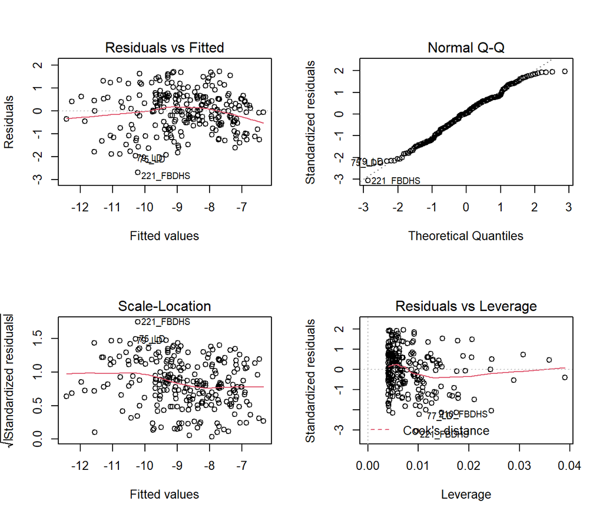

```r
par(mfrow = c(2, 2))
plot(mod_training_without_GC)
```

### 7.1.2 lm model with GC

```r
summary(mod_training_with_GC)
```

```
##
## Call:
## lm(formula = log2(RNA_prop_mean) ~ log2(DNA_prop_mean) + GC,
##     data = data.for.lm)
##
## Residuals:
##      Min       1Q   Median       3Q      Max
## -2.41881 -0.51358  0.00041  0.50422  1.77789
##
## Coefficients:
##                     Estimate Std. Error t value Pr(>|t|)
## (Intercept)           2.2888     0.6315   3.624 0.000352 ***
## log2(DNA_prop_mean)   1.0490     0.0446  23.520  < 2e-16 ***
## GC                   -4.7033     0.8592  -5.474 1.09e-07 ***
## ---
## Signif. codes:  0 '***' 0.001 '**' 0.01 '*' 0.05 '.' 0.1 ' ' 1
##
## Residual standard error: 0.8366 on 245 degrees of freedom
## Multiple R-squared:  0.703,  Adjusted R-squared:  0.7006
## F-statistic: 289.9 on 2 and 245 DF,  p-value: < 2.2e-16
```

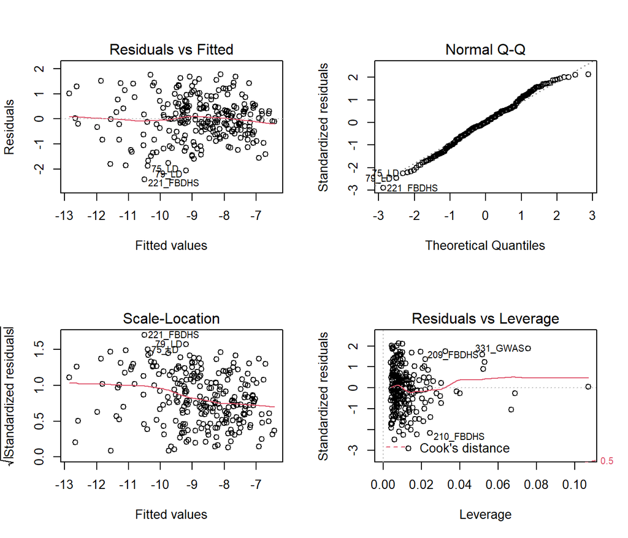

```r
par(mfrow = c(2, 2))
plot(mod_training_with_GC)
```

BIC without GC covariate

```r
BIC(mod_training_without_GC)
```

```
## [1] 657.4324
```

BIC with GC covariate. Lower value justifies GC addition to the model.

```r
BIC(mod_training_with_GC)
```

```
## [1] 634.3285
```

```r
## use lm to predict residuals of dataset for prediction (data.predict)
# consider data.clean with 308 amplicons

# data.predict <- dplyr::filter(data.all, Pass_DNA_count == TRUE) # 321 amplicons

# NOTE: This edit has not been approved yet:
data.predict <- data.clean  # KC: replaced by data.clean to limit the confusion from showing amplicons with reduced activity that do not pass stringent QC.

predict_data.predict <- predict(mod_training_with_GC, newdata = data.predict, interval = "confidence")
predict_data.predict <- as.data.frame(predict_data.predict)

## append both lms to data.predict
data.predict <- data.frame(data.predict, predict_data.predict)
data.predict$Residuals_Manual <- log2(data.predict$RNA_prop_mean) - data.predict$fit


## calculate residual z-scores (res - mean)/sd
## z-scores are scaled to training distribution used for fitting

# I'm scaling the Z scores to the training distribution, the one used for fitting the model
lm_sd <- sd(mod_training_with_GC$residuals)
lm_mean <- mean(mod_training_with_GC$residuals)

data.predict$Residuals_Z_scaled_to_lm <- (data.predict$Residuals_Manual - lm_mean) / lm_sd

# Calculate normal p values
data.predict$Pvalue <- pnorm(data.predict$Residuals_Z_scaled_to_lm, lower.tail = FALSE)
data.predict$FDR <- p.adjust(data.predict$Pvalue, method = "BH")

#sum(data.predict$Pvalue < 0.05)
#sum(data.predict$Pvalue < 0.05 & data.predict$Residuals_Z_scaled_to_lm > 0)
#sum(data.predict$Pvalue < 0.05 & data.predict$Residuals_Z_scaled_to_lm < 0)

# Are residuals normally distributed. Graphical approach = PASSED  KC: there was a plot here...
#write.csv(data.predict, file = "G:/Shared drives/Nord Lab - Computational #Projects/MPRA/STAR408/CSV_output_files/STAR408_data.predict.N321.csv",
#            quote = FALSE, row.names = FALSE)
```

## 7.2 Model exploratory plots - under construction

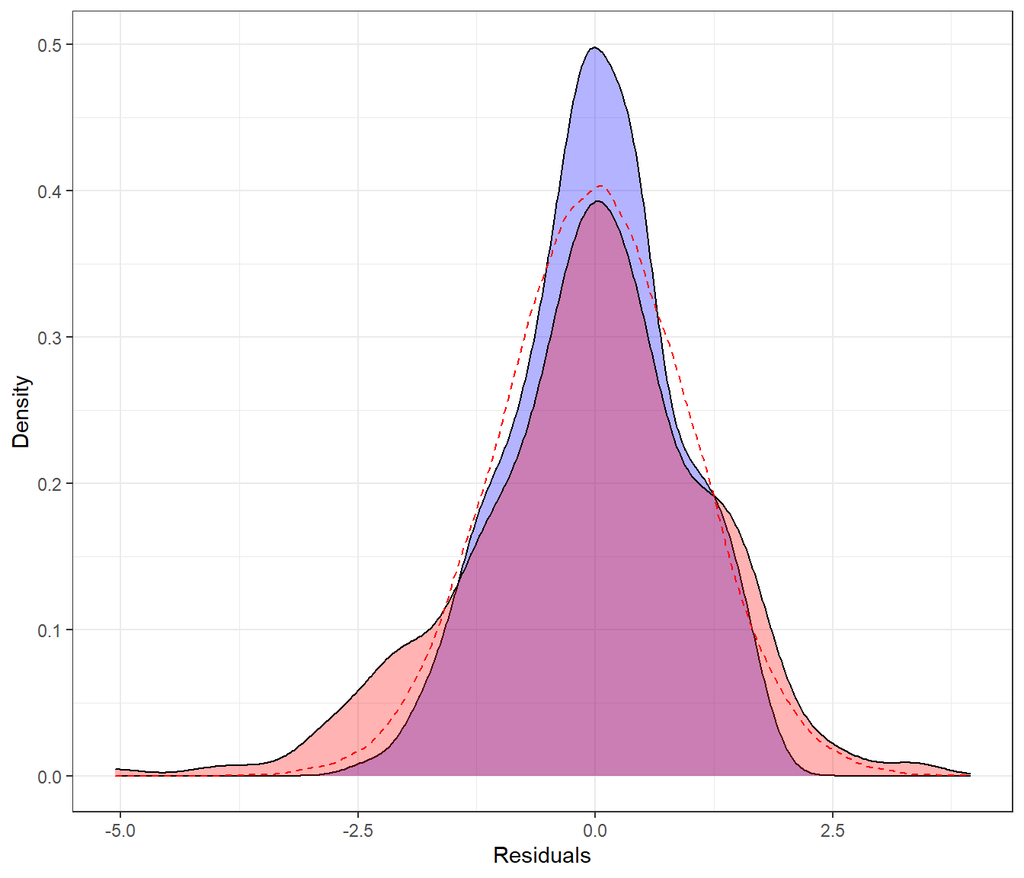

```r
data.predict$training <- ifelse(data.predict$Amp_name %in% data.for.lm$Amp_name, TRUE, FALSE)

# make a normal distribution with s.d. = 1
r_norm <- rnorm(n = 50000, sd = 1)

# Training - Raw
ggplot()+
  geom_density(data = dplyr::filter(data.predict, training == TRUE), aes(x = Residuals_Manual),
               fill = "blue", alpha = 0.3) +
  geom_density(data = data.predict, aes(x = Residuals_Manual),
               fill = "red", alpha = 0.3) +
  geom_density(data = data.frame("r_norm" = r_norm),
               aes(x = r_norm), color = "red", linetype = 2, alpha = 0)+
  labs(x = "Residuals", y = "Density") +
  theme_bw()
```

## 7.3 Major figures

### 7.3.1 Fig. 1D

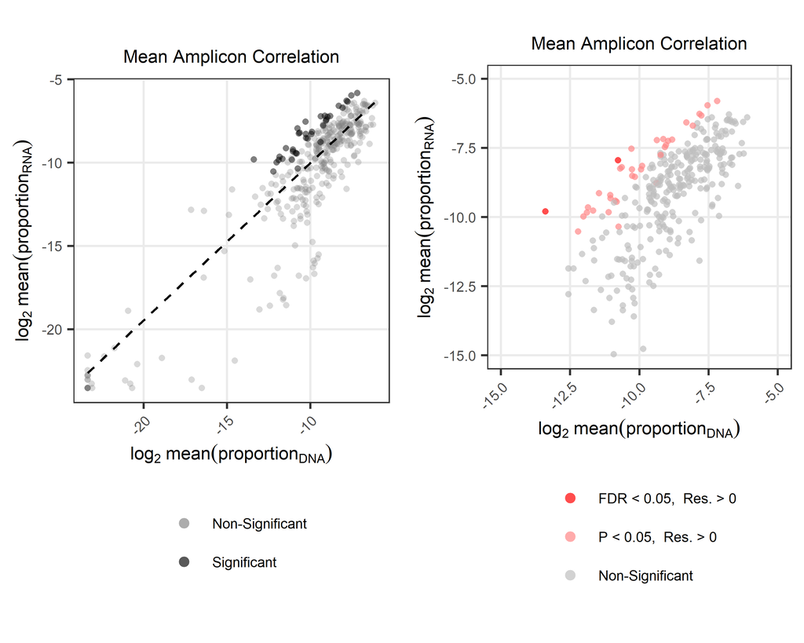

```r
# Left

p1 <- ggplot() +
  geom_point(data = data.all[! data.all$Amp_name %in% data.predict$Amp_name[data.predict$Pvalue < 0.05],],
             aes(x = log2(DNA_prop_mean), y = log2(RNA_prop_mean), color = "Non-Significant"),
             alpha = 0.3, size = 1, shape = 16) +
  geom_point(data = data.predict[data.predict$Pvalue < 0.05,],
             aes(x = log2(DNA_prop_mean), y = log2(RNA_prop_mean), color = "Significant"),
             alpha = 0.5, size = 1, shape = 16) +
  scale_color_manual(values = c("Significant" = "black",
                                "Non-Significant" = "grey50")) +
  labs(title = "Mean Amplicon Correlation", color = NULL,
       x = bquote(log[2]~mean(proportion[DNA])),
       y = bquote(log[2]~mean(proportion[RNA]))) +
  geom_smooth(data = data.for.lm, aes(x = log2(DNA_prop_mean), y = log2(RNA_prop_mean)),
              formula = y ~ x, method = 'lm', se = F, color = "black", size = 0.5, linetype = 2, fullrange = T) +
  # lims(x = c(-15,-5), y = c(-20, -5)) +
  coord_fixed() +
  guides(color = guide_legend(ncol = 1, override.aes = list(size = 2))) +
  theme_bw() + theme(text = element_text(size = 8),
                     plot.title = element_text(size = 8, hjust = 0.5),
                     axis.text.x = element_text(angle = 45, hjust = 1, vjust = 1),
                     legend.position = "right")+
   theme(panel.grid.minor = element_blank())

#p1

#ggsave("G:/Shared drives/Nord Lab - Temp Overflow/STARR-408_Lambert&Su-Feher/Draft Figures/Figure #1/FIG1D_AllData_with_lm_KC.svg",
#       plot = p1, dpi = 300, width = 3, height = 5)

#ggsave("G:/Shared drives/Nord Lab - Temp Overflow/STARR-408_Lambert&Su-Feher/Draft Figures/Figure #1/FIG1D_AllData_with_lm_KC.png",
#       plot = p1, dpi = 300, width = 3, height = 5)

# Right

# Gradation of data filtering steps:

# 1. data.all = 407 amplicons

# data.clean = 308 amplicons; Passed_QC (Pass_DNA_count, Pass_prop_DNA_and_RNA) &
#                                                 At_least_1_specific_in_sil_prod
# NOTE: data.clean was used for selecting the training set of 248 amplicons, and 30 + 30 tails

# data.predict = 321 amplicons; Pass_DNA_count, relaxed data.clean set. Edited. Now data.predict = data.clean



## FIGURE 1C with data.predict

# This is effectively replacing data.predict with data.clean)
fig.1c <- data.predict

# Significance annotation
fig.1c$Sig <- ifelse(fig.1c$Pvalue >= 0.05, "Non-Significant", "P < 0.05,  Res. > 0")

fig.1c$Sig <- ifelse(fig.1c$Pvalue < 0.05 & fig.1c$Residuals_Manual < 0,
                         "P < 0.05,  Res. < 0", fig.1c$Sig)

fig.1c$Sig <- ifelse(fig.1c$FDR < 0.05 & fig.1c$Residuals_Manual > 0,
                         "FDR < 0.05,  Res. > 0", fig.1c$Sig)

fig.1c$Sig <- ifelse(fig.1c$FDR < 0.05 & fig.1c$Residuals_Manual < 0,
                         "FDR < 0.05,  Res. < 0", fig.1c$Sig)

# Order plot legend
fig.1c$Sig <- factor(fig.1c$Sig, levels = c("FDR < 0.05,  Res. > 0", "P < 0.05,  Res. > 0", "FDR < 0.05,  Res. < 0", "P < 0.05,  Res. < 0", "Non-Significant"))


p2 <- ggplot(fig.1c, aes(x = log2(DNA_prop_mean), y = log2(RNA_prop_mean), color = Sig))+
             geom_point(alpha = 0.7, size = 1, shape = 16)+

 scale_color_manual(values = c("Non-Significant" = "grey",
                               "P < 0.05,  Res. > 0" = "#ff8787",
                               "FDR < 0.05,  Res. > 0" = "#ff0000",
                               "P < 0.05,  Res. < 0" = "#8c8cff",
                               "FDR < 0.05,  Res. < 0" = "#0000ff"))+

  labs(title = "Mean Amplicon Correlation", color = NULL,
       x = bquote(log[2]~mean(proportion[DNA])),
       y = bquote(log[2]~mean(proportion[RNA]))) +
  lims(x = c(-15,-5), y = c(-15, -5)) +
  coord_fixed() +
  guides(color = guide_legend(ncol = 1, override.aes = list(size = 2))) +
  theme_bw() + theme(text = element_text(size = 8),
                     plot.title = element_text(size = 8, hjust = 0.5),
                     axis.text.x = element_text(angle = 45, hjust = 1, vjust = 1),
                     legend.position = "right")+
  theme(panel.grid.minor = element_blank())

 #p2

# ggsave("G:/Shared drives/Nord Lab - Temp Overflow/STARR-408_Lambert&Su-Feher/Draft Figures/Figure #1/FIG1D_CleanedData_by_P_and_Residual_KCv2.png",
#       plot = p2, dpi = 300, width = 3, height = 5)

#ggsave("G:/Shared drives/Nord Lab - Temp Overflow/STARR-408_Lambert&Su-Feher/Draft Figures/Figure #1/FIG1D_CleanedData_by_P_and_Residual_KCv2.svg",
#       plot = p2, dpi = 300, width = 3, height = 5)

 #

library(gridExtra)

grid.arrange(p1+theme(legend.position = "bottom"),
             p2+theme(legend.position = "bottom"),
             nrow = 1)
```

### 7.3.2 Summary table

```r
# Coordinates are in GRCh38

datatable(
  arrange(data.predict, desc(Residuals_Z_scaled_to_lm))[,c("Amp_name", "Chr", "Start", "End", "MeanRatio", "MeanRatio_sd", "training", "Residuals_Z_scaled_to_lm", "Pvalue", "FDR")],
  rownames = FALSE)
```

| Amp_name | Chr | Start | End | MeanRatio | MeanRatio_sd | training | Residuals_Z_scaled_to_lm | Pvalue | FDR |
| --- | --- | --- | --- | --- | --- | --- | --- | --- | --- |
| 122_FBDHS | 2 | 148302908 | 148303799 | 11.4508699474375 | 12.4689078195579 | False | 4.11537710362199 | 1.93273457209394e-05 | 0.00595282248204933 |
| 116_GWAS | 3 | 168143186 | 168144057 | 14.8310636410235 | 15.5810716515943 | False | 3.93598865977796 | 4.14274427378779e-05 | 0.0063798261816332 |
| 259_PutEnh_Scn1a | 2 | 166127199 | 166128139 | 7.7351581842478 | 6.66407518136072 | False | 3.19893190725954 | 0.000689688721406 | 0.0708080420643493 |
| 149_FBDHS | 2 | 165471186 | 165472085 | 8.00266945395477 | 6.19727695466735 | False | 3.0939282741345 | 0.000987626168932574 | 0.0760472150078082 |
| 291_GWAS | 2 | 192983147 | 192984037 | 6.4271507264406 | 3.41453858516316 | False | 2.83617705879523 | 0.00228285632347222 | 0.140623949525889 |
| 161_FBDHS | 2 | 165500720 | 165501601 | 5.74463503642565 | 1.59961596579304 | False | 2.73834790529188 | 0.00308743574608005 | 0.158488368298776 |
| 387_GWAS | 16 | 13655540 | 13656472 | 26.778415540466 | 49.7013528997056 | False | 2.63094911216981 | 0.00425733921856061 | 0.187322925616667 |
| 28_GWAS | 3 | 21677299 | 21678198 | 5.25210166593749 | 3.51040250042048 | False | 2.36007656317068 | 0.00913558185286432 | 0.340467470832248 |
| 144_FBDHS | 2 | 165466767 | 165467638 | 15.8837163066851 | 26.2797653532863 | False | 2.32827606132319 | 0.00994872479704622 | 0.340467470832248 |
| 213_FBDHS | 16 | 6969312 | 6970228 | 3.53450496130676 | 0.916756918364694 | False | 2.284716823643 | 0.011164718752421 | 0.342934341721343 |

[output cut: 298 more lines]

### 7.3.3 Fig. 2A

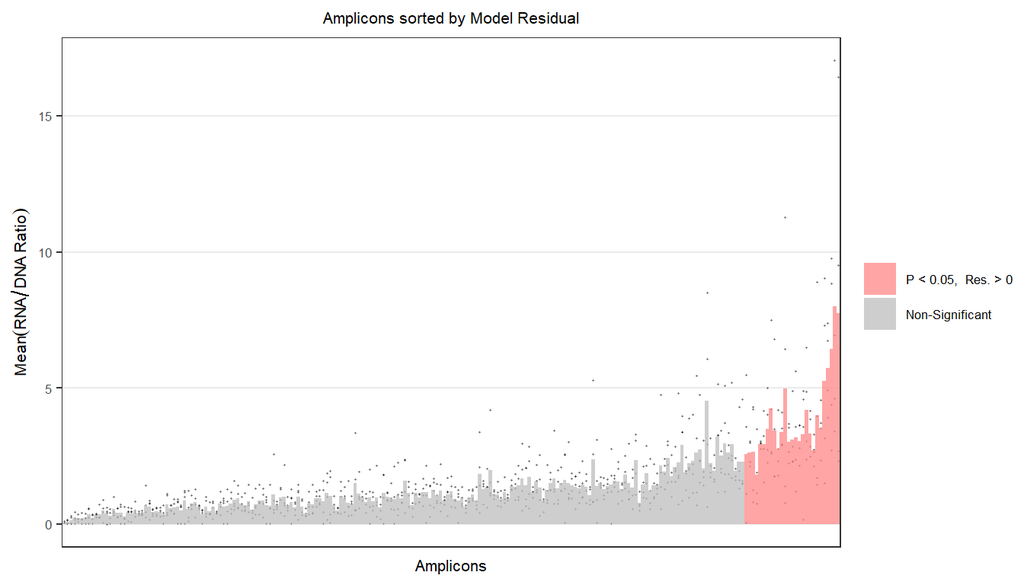

Fig. 2A. Bar plot representing distribution of activity in the test assay, sorted by linear model residual. Amplicons are colored as in Figure 1D. MPRA amplicons passing Passed_QC_with_SD; DNA prop > 2^-15 & RNA prop > 2^-15 & DNA count > 200 in all 4 samples; n = 219 amplicons

```r
## FIG1D Variant: Bar plot with ratio mean and all 4 samples for ALL data,
## and inset showing just sig (p < 0.05) for up and down

fig.1d.bar <- data.predict

# DNA prop + RNA prop + DNA count  = PASSED
fig.1d.bar <- fig.1d.bar[fig.1d.bar$Passed_QC_with_SD == TRUE, ]

# Significance annotation
fig.1d.bar$Sig <- ifelse(fig.1d.bar$Pvalue >= 0.05, "Non-Significant", "P < 0.05,  Res. > 0")

fig.1d.bar$Sig <- ifelse(fig.1d.bar$Pvalue < 0.05 & fig.1d.bar$Residuals_Manual < 0,
                         "P < 0.05,  Res. < 0", fig.1d.bar$Sig)

fig.1d.bar$Sig <- ifelse(fig.1d.bar$FDR < 0.05 & fig.1d.bar$Residuals_Manual > 0,
                         "FDR < 0.05,  Res. > 0", fig.1d.bar$Sig)

fig.1d.bar$Sig <- ifelse(fig.1d.bar$FDR < 0.05 & fig.1d.bar$Residuals_Manual < 0,
                         "FDR < 0.05,  Res. < 0", fig.1d.bar$Sig)


# Reordering based on Residuals
fig.1d.bar <- fig.1d.bar[order(fig.1d.bar$Residuals_Manual, decreasing = F),]
fig.1d.bar$Amp_name <- factor(fig.1d.bar$Amp_name, levels = fig.1d.bar$Amp_name)


fig.1d.bar.melt <- melt(fig.1d.bar[,c("Amp_name", "L1_Activity", "L2_Activity", "L3_Activity", "L4_Activity", "Sig")], id.vars = c("Amp_name", "Sig"))

#head(fig.1d.bar.melt)

# set hard limits
fig.1d.bar.melt$value <- fig.1d.bar.melt$value

fig.1d.bar.melt$value <- ifelse(fig.1d.bar.melt$value < -20, -20,  fig.1d.bar.melt$value)
fig.1d.bar.melt$value <- ifelse(fig.1d.bar.melt$value > 20, 20,  fig.1d.bar.melt$value)

fig.1d.bar$MeanRatio <- fig.1d.bar$MeanRatio
fig.1d.bar$MeanRatio <- ifelse(fig.1d.bar$MeanRatio < -20, -20,  fig.1d.bar$MeanRatio)
fig.1d.bar$MeanRatio <- ifelse(fig.1d.bar$MeanRatio > 20, 20,  fig.1d.bar$MeanRatio)

# Order plot legend
fig.1d.bar$Sig <- factor(fig.1d.bar$Sig, levels = c("FDR < 0.05,  Res. > 0", "P < 0.05,  Res. > 0", "FDR < 0.05,  Res. < 0", "P < 0.05,  Res. < 0", "Non-Significant"))

# Plot
p <- ggplot(fig.1d.bar)+
  geom_point(data = fig.1d.bar.melt,
             aes(x = Amp_name, y = value),
             size = 0.2, alpha = 0.5, color = "black", shape = 16)+

  geom_bar(data = fig.1d.bar,
           aes(x = Amp_name, y = MeanRatio, fill = Sig),
           stat = "identity", alpha = 0.75, width = 1)+

  scale_fill_manual(values = c("Non-Significant" = "grey",
                               "P < 0.05,  Res. > 0" = "#ff8787",
                               "FDR < 0.05,  Res. > 0" = "#ff0000",
                               "P < 0.05,  Res. < 0" = "#8c8cff",
                               "FDR < 0.05,  Res. < 0" = "#0000ff"))+

  labs(x = "Amplicons",
       y = bquote(Mean(RNA/DNA~Ratio)),
       fill = NULL,
       title = "Amplicons sorted by Model Residual")+
  theme_bw()+
  theme(text = element_text(size = 8),
                     plot.title = element_text(size = 8, hjust = 0.5),
                     axis.text.x = element_blank(),
                     axis.ticks.x = element_blank(),
                     # panel.background = element_rect(fill = "white"),
                     panel.grid.major.x = element_blank(),
                     panel.grid.minor = element_blank(),
                     # panel.grid.major.y = element_line(size = 0.5),
                     legend.position = "right", legend.margin = margin(0,0,0,0))

p
```

```r
ggsave("G:/Shared drives/Nord Lab - Temp Overflow/STARR-408_Lambert&Su-Feher/Draft Figures/Figure 2/Fig2A_Var_BarPlot_MeanRatio_with_Points_KC.svg",
       plot = p, dpi = 300, width = 6, height = 3)

ggsave("G:/Shared drives/Nord Lab - Temp Overflow/STARR-408_Lambert&Su-Feher/Draft Figures/Figure 2/Fig2A_Var_BarPlot_MeanRatio_with_Points_KC.png",
       plot = p, dpi = 300, width = 6, height = 3)
```

### 7.3.4 Fig. 2B

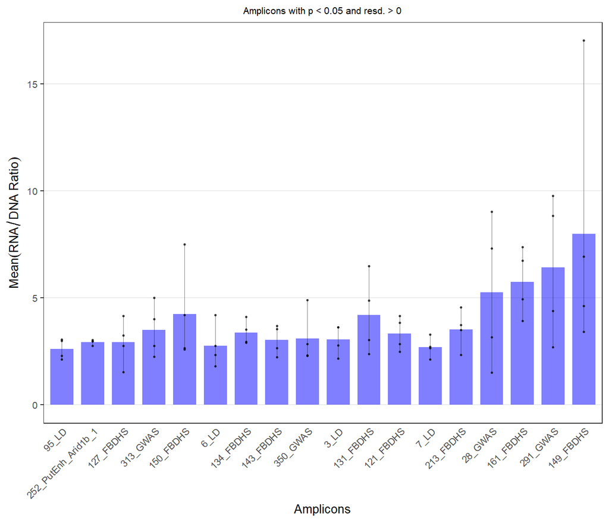

Fig.2B. The top 18 active amplicons with consistent activity across both linear models and ratiometric models. Three amplicons were used for downstream validation in single-candidate deliveries (6_LD, 3_LD, 161_FBDHS). Bar for all plots represents mean RNA/DNA ratio. Each dot represents individual RNA/DNA ratios for each amplicon (4 dots per amplicon).

```r
## Sanity check for reporting amplicon number
df <- data.predict
df$MeanRatio_m_SD <- df$MeanRatio - df$MeanRatio_sd
#nrow(df) # 308 all amplicons
#nrow(filter(df, Pvalue < 0.05)) # 77  Significant amplicons
#nrow(filter(df, Pvalue < 0.05, Residuals_Z_scaled_to_lm > 0)) # 36 positive amplicons
#nrow(filter(df, Pvalue < 0.05, Residuals_Z_scaled_to_lm > 0, MeanRatio_m_SD > 1.5)) # 18 positive amplicons with (MeanRatio - MeanRatio_sd) > 1.5

#nrow(filter(df, MeanRatio_m_SD > 0, MeanRatio > 1.5)) # 71 amplicons with mean ration > 1 SD, and mean ration > 1.5

active_amplicons_in_regression_model <- filter(df, Pvalue < 0.05, Residuals_Z_scaled_to_lm > 0)$Amp_name  # 36 amplicons
active_amplicons_in_ratiometric_comparison <- filter(df, MeanRatio > 1)$Amp_name                          # 156 amplicons

#setdiff(active_amplicons_in_regression_model, active_amplicons_in_ratiometric_comparison) # 0 amplicons = complete inclusion of active_amplicons_in_regression_model


# Figure 2B, Fig2B

fig.1d.bar <- filter(df, Pvalue < 0.05, Residuals_Z_scaled_to_lm > 0, MeanRatio_m_SD > 1.5)
#dim(fig.1d.bar)

# Color addition is unnecessary
fig.1d.bar$Color <- ifelse(fig.1d.bar$Pvalue >= 0.05, "Non-Significant", "Significant (resd. > 0)")
fig.1d.bar$Color <- ifelse(fig.1d.bar$Pvalue < 0.05 & fig.1d.bar$Residuals_Manual < 0, "Significant (resd. < 0)", fig.1d.bar$Color)

fig.1d.bar <- fig.1d.bar[order(fig.1d.bar$Residuals_Manual, decreasing = F),]
fig.1d.bar$Amp_name <- factor(fig.1d.bar$Amp_name, levels = fig.1d.bar$Amp_name)

fig.1d.bar.melt <- melt(fig.1d.bar[,c("Amp_name", "L1_Activity", "L2_Activity", "L3_Activity", "L4_Activity")], id.vars = "Amp_name")

p <- ggplot(fig.1d.bar) +
  geom_bar(data = fig.1d.bar,
           aes(x = Amp_name, y = MeanRatio, fill = Color),
           stat = "identity", alpha = 0.5, width = 0.75) +
  geom_line(data = fig.1d.bar.melt,
            aes(x = Amp_name, y = value, group = Amp_name),
            size = 0.25, alpha = 0.5, color = "black") +
  geom_point(data = fig.1d.bar.melt,
             aes(x = Amp_name, y = value),
             size = 0.5, alpha = 0.75, color = "black", shape = 16) +
  labs(x = "Amplicons",
       y = bquote(Mean(RNA/DNA~Ratio)),
       fill = NULL,
       title = "Amplicons with p < 0.05 and resd. > 0") +
  theme_bw() + theme(text = element_text(size = 8),
                     plot.title = element_text(size = 8, hjust = 0.5),
                     axis.text.x = element_blank(),
                     axis.ticks.x = element_blank(),
                     # panel.background = element_rect(fill = "white"),
                     panel.grid.major.x = element_blank(),
                     panel.grid.minor = element_blank(),
                     # panel.grid.major.y = element_line(size = 0.5),
                     legend.position = "none")+
  scale_fill_manual(values = c("Significant (resd. > 0)" = "blue",
                               "Significant (resd. < 0)" = "red",
                               "Non-Significant" = "grey50"))+
  theme(text = element_text(size = 10), axis.text.x = element_text(angle = 45, hjust = 1, vjust = 1))

p
```

# 8. Epigenomic intersections

## 8.1 Roadmap data download

```r
# Original version of this analysis can be found here:

require("RCurl")
library(XML)
library(R.utils)

# Sample identity: https://egg2.wustl.edu/roadmap/web_portal/processed_data.html
# E81 - Fetal Brain Male
# E82 - Fetal Brain Female

#setwd("G:/Shared drives/Nord Lab - Computational Projects/MPRA/STAR408/Epigenomics_intersections")

# Creates a subdir for downloading Roadmap peak data
peak_dir <- "Roadmap_consolidated_peaks/"
dir.create(peak_dir, showWarnings = FALSE)

# Downloads data
url_narrowPeak = "https://egg2.wustl.edu/roadmap/data/byFileType/peaks/consolidated/narrowPeak/"

# Get links
result <- getURL(url_narrowPeak, verbose=TRUE, ftp.use.epsv=TRUE, dirlistonly = TRUE)
gz_files <- getHTMLLinks(result,  xpQuery = "//a/@href[contains(., '.gz')]")
download_files <- gz_files[grepl("E081|E082", gz_files)]        # grepl Male and Female fetal samples

# Check if files are present in a directory:
if(all(list.files(peak_dir) %in% gsub(".gz","", download_files))){

  message("Files exist")

} else {


# Proactively removes all files in the peak_dir
setwd(peak_dir)
file.remove(list.files())
setwd("../")

# Download
sapply(download_files, function(x)
  download.file(paste0(url_narrowPeak, x), paste0(peak_dir, x)))

# Gunzip
sapply(download_files, function(x)
  gunzip(paste0(peak_dir, x)))

}
```

## 8.2 Adding hg19 coordinates

```r
# Reading and preparing amplicons and hg19 primer coordinate data

# I'm merging primers and star datasets to translate GRCh38 to hg19.
# Primers use hg19 coordinates. star408 amplicons use GRCh38 coordinates. isPCR was also run against GRCh38 genome.

primers <- read.csv("G:/Shared drives/Nord Lab - Computational Projects/MPRA/STAR408/In_silico_PCR_STAR408/STAR408_primers.csv", header = TRUE, fill = TRUE)

primers$Chr <- gsub('.*?([0-9XY]+).*', '\\1', primers$Amplicon.Range)
amp_range <- gsub('.*?[0-9XY]+:(d*)+d*', '\\1', primers$Amplicon.Range)
primers$Start <- gsub('([^+]*).*', '\\1', amp_range, perl = TRUE)
primers$Stop <-gsub('.*\\+([^+]*)', '\\1', amp_range, perl = TRUE)
primers <- primers[,c(12:14, 1:11)]

hg19_coordinates <- primers[,c(1:3, 12)]
#head(hg19_coordinates)

# Readign the final MPRA analysis set
# star408 <- read.csv("G:/Shared drives/Nord Lab - Computational Projects/MPRA/STAR408/CSV_output_files/STAR408_lm_model_complete_dataset_408_amplicons.csv")
# amplicons_309 <- filter(star408, Pass_prop_DNA_and_RNA == TRUE, Pass_DNA_count == TRUE)

#amplicons_321 <- read.csv("G:/Shared drives/Nord Lab - Computational Projects/MPRA/STAR408/CSV_output_files/STAR408_data.predict.N321.csv")

# NOTE: KC. Earlier version was using an expanded set of 321 amplicons. We are reverting to a set of 308 for consistency and stringency.

# Amp_Full_Name
#data.predict$Amp_name

# Linda changed amp names. I'll be matching Amp names in primers / hg19_coordinates so I can merge them.
#hg19_coordinates$Amplicon
hg19_coordinates$Amplicon.ID_new <- gsub("Epilepsy", "EPIL", hg19_coordinates$Amplicon)
hg19_coordinates$Amplicon.ID_new <- gsub("SZ108", "SCZ", hg19_coordinates$Amplicon.ID_new)
hg19_coordinates$Amplicon.ID_new <- gsub("NCASD", "FBDHS", hg19_coordinates$Amplicon.ID_new)
hg19_coordinates$Amplicon.ID_new <- gsub("Controls", "PutEnh", hg19_coordinates$Amplicon.ID_new)

#hg19_coordinates$Amplicon.ID_new

data.predict$Amp_Full_Name <- gsub("Epilepsy", "EPIL", data.predict$Amp_Full_Name)
data.predict$Amp_Full_Name <- gsub("SZ108", "SCZ", data.predict$Amp_Full_Name)
data.predict$Amp_Full_Name <- gsub("NCASD", "FBDHS", data.predict$Amp_Full_Name)
data.predict$Amp_Full_Name <- gsub("Controls", "PutEnh", data.predict$Amp_Full_Name)
data.predict$Amp_Full_Name <- gsub("Control", "PutEnh", data.predict$Amp_Full_Name)

data.predict$Amp_Full_Name <- gsub("252_PutEnh_Arid1b_1", "252_PutEnh", data.predict$Amp_Full_Name)
data.predict$Amp_Full_Name <- gsub("253_PutEnh_NEG1", "253_PutEnh", data.predict$Amp_Full_Name)
data.predict$Amp_Full_Name <- gsub("255_PutEnh_Klhl32_hs676", "255_PutEnh", data.predict$Amp_Full_Name)
data.predict$Amp_Full_Name <- gsub("257_PutEnh_Btrc_hs897", "257_PutEnh", data.predict$Amp_Full_Name)
data.predict$Amp_Full_Name <- gsub("258_PutEnh_Arx_hs122", "258_PutEnh", data.predict$Amp_Full_Name)
data.predict$Amp_Full_Name <- gsub("259_PutEnh_Scn1a", "259_PutEnh", data.predict$Amp_Full_Name)
data.predict$Amp_Full_Name <- gsub("264_PutEnh_NEG4", "264_PutEnh", data.predict$Amp_Full_Name)
data.predict$Amp_Full_Name <- gsub("266_PutEnh_Etv1_hs550", "266_PutEnh", data.predict$Amp_Full_Name)

# Arid1b_1 and Arid1b_3 are overlapping. Dropping Arid1b_3.
hg19_coordinates <- hg19_coordinates[!hg19_coordinates$Amplicon.ID_new == "265_PutEnh",]

#data.frame(data.predict$Amp_name, data.predict$Amp_name2, data.predict$Amp_Full_Name)

#setdiff(hg19_coordinates$Amplicon.ID_new, data.predict$Amp_Full_Name) # 99
#setdiff(data.predict$Amp_Full_Name, hg19_coordinates$Amplicon.ID_new) # 0 - fixed



#head(hg19_coordinates)
#head(data.predict)
colnames(hg19_coordinates) <- c("Chr_hg19", "Start_hg19", "Stop_hg19", "Amplicon.ID", "Amplicon.ID_new")

data.predict_w_hg19_coord <- merge(hg19_coordinates, data.predict,
                                    by.x = "Amplicon.ID_new", by.y = "Amp_Full_Name")

colnames(data.predict_w_hg19_coord) <-  gsub("\\<Start\\>","Start_GRCh38", colnames(data.predict_w_hg19_coord))
colnames(data.predict_w_hg19_coord) <-  gsub("\\<End\\>","End_GRCh38", colnames(data.predict_w_hg19_coord))
colnames(data.predict_w_hg19_coord) <-  gsub("\\<Chr\\>","Chr_GRCh38", colnames(data.predict_w_hg19_coord))

#colnames(data.predict_w_hg19_coord)

#nrow(data.predict_w_hg19_coord)
#nrow(hg19_coordinates)
#nrow(data.predict)

# Generating MPRA GR object
data.predict_w_hg19_coord <- data.predict_w_hg19_coord[,c(2:4, 7:9, 1,5, 10:67)]
colnames(data.predict_w_hg19_coord) <- c("Chr", "Start", "End", colnames(data.predict_w_hg19_coord)[4:66])


data.predict_w_hg19_coord$Chr <- paste0("chr", data.predict_w_hg19_coord$Chr) # For compatibility
data.predict_w_hg19_coord_GR <- makeGRangesFromDataFrame(data.predict_w_hg19_coord)
values(data.predict_w_hg19_coord_GR) <- data.predict_w_hg19_coord[,4:66]
```

## 8.3 Calculate intersections

```r
source("epi_mark_intersection.R")
library(data.table)

# Calculate interactions
calculate_interactions <- function(samples, epi_marks, q_values){

l <- lapply(epi_marks, function(y){
lapply(q_values, function(x){

  epi_mark_intersection(y, samples, x)

  })
})

df <- rbindlist(lapply(1:length(l), function(x) rbindlist(l[[x]])))  # there must be a better way...

df$Epi_mark <- gsub("DNase.macs2", "DNase", df$Epi_mark)

df$Significance <- ifelse(df$P_values_sampling >= 0.05, "Non-significant", "NA")
df$Significance <- ifelse(df$P_values_sampling < 0.05, "P < 0.05", df$Significance)
df$Significance <- ifelse(df$P_values_sampling < 0.01, "P < 0.01", df$Significance)


df_m <- melt(df, id.vars = c("Condition", "Epi_mark", "Epi_peak_q_value", "Fraction_intersecting", "P_values_sampling", "Significance"))

df_m <- arrange(df_m, desc(Epi_peak_q_value))
df_m$Epi_peak_q_value <- factor(df_m$Epi_peak_q_value, levels = unique(as.numeric(df_m$Epi_peak_q_value)))

# Peak mark order
df_m$Epi_mark <- factor(df_m$Epi_mark, levels = c("DNase", "H3K27ac", "H3K9ac", "H3K4me1", "H3K4me3", "H3K36me3", "H3K9me3", "H3K27me3"))

# Better condition names
df_m$Condition <- ifelse(df_m$Condition == "Low", "Low, P < 0.05", df_m$Condition)
df_m$Condition <- ifelse(df_m$Condition == "High", "High, P < 0.05", df_m$Condition)
df_m$Condition <- ifelse(df_m$Condition == "Middle", "Middle, P > 0.05", df_m$Condition)

# Legend items order
df_m$Condition <- factor(df_m$Condition, levels = c("High", "High, P < 0.05",
                                                    "Middle", "Middle, P > 0.05",
                                                    "Low", "Low, P < 0.05"))

df_m$Significance <- factor(df_m$Significance, levels = c("P < 0.01", "P < 0.05","Non-significant"))

df_m

}

# Male and Female "E081", "E082" datasets are merged together in this approach. Intersection indicates overlap between any of the samples.


# This is loaded from a file to speed up report generation
if(file.exists("Epi_interst.RData")){

  load("Epigenomics_intersections/Epi_interst.RData")

} else {

df_m <- calculate_interactions(c("E081", "E082"),
                               c("DNase.macs2", "H3K27me3", "H3K36me3", "H3K4me1", "H3K4me3", "H3K9me3"),
                               c(1, 0.05, 0.01))

#save(df_m, file = "Epi_interst.RData")

}

# Simplifies condition names:
  df_m$Condition <- ifelse(df_m$Condition == "Low, P < 0.05", "Low", as.character(df_m$Condition))
  df_m$Condition <- ifelse(df_m$Condition == "Middle, P > 0.05", "Middle", as.character(df_m$Condition))
  df_m$Condition <- ifelse(df_m$Condition == "High, P < 0.05", "High", as.character(df_m$Condition))
```

## 8.4 Intersections across peak q values

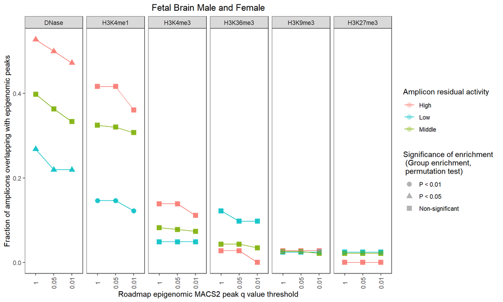

```r
# Intersections across Peak q values
title = "Fetal Brain Male and Female"

ggplot(df_m, aes(x = Epi_peak_q_value, y = Fraction_intersecting, color = Condition, group = Condition,
                 shape = Significance))+
  geom_point(size = 3, alpha = 0.3)+
  geom_line()+
  labs(x = "Roadmap epigenomic MACS2 peak q value threshold", y = paste0("Fraction of amplicons overlapping with epigenomic peaks"))+
  expand_limits(y = 0)+
  theme_bw()+
  theme(plot.title = element_text(hjust = 0.5))+
  facet_grid(~Epi_mark)+
  theme(axis.text.x = element_text(angle = 90, vjust = 0.5))+
  labs(title = title)+
  labs(shape='Significance of enrichment \n (Group enrichment, \n permutation test)')+
  labs(color='Amplicon residual activity')+
  scale_color_manual(values=c("High" = "#F8766D",
                              "Middle" = "#7CAE00",
                              "Low" = "#00BFC4"))+
  guides(
   shape = guide_legend(order = 2),
   color = guide_legend(order = 1)
  )+
  theme(panel.grid.major = element_blank(), panel.grid.minor = element_blank())
```

## 8.5 Intersections across peak q values

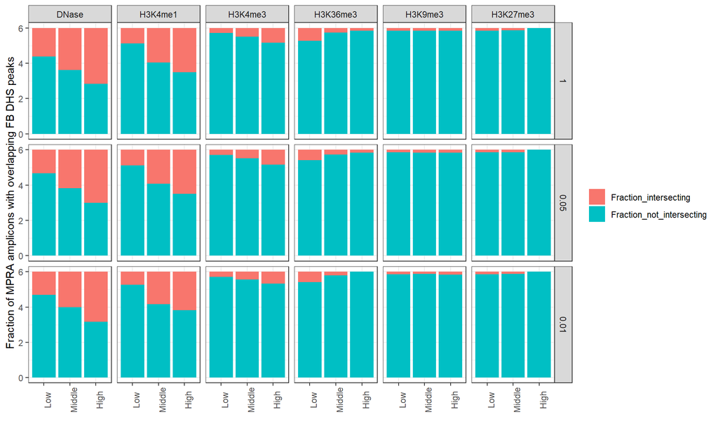

```r
# Stacked barplot representation

df2 <- df_m
df2$Fraction_not_intersecting <- 1- df2$Fraction_intersecting
df2 <- df2[,c("Condition", "Epi_mark", "Fraction_intersecting", "Fraction_not_intersecting",  "Epi_peak_q_value")]

df2_m <- melt(df2, id.vars = c("Condition", "Epi_mark", "Epi_peak_q_value"))

df2_m$Epi_mark <- factor(df2_m$Epi_mark, levels = c("DNase", "H3K4me1", "H3K4me3", "H3K36me3", "H3K9me3", "H3K27me3"))
df2_m$Condition <- factor(df2_m$Condition, levels = c("Low", "Middle", "High"))

### Stacked barplot - all peak significance levels
ggplot(df2_m, aes(fill = variable, y=value, x=Condition)) +
    geom_bar(position="stack", stat="identity")+
    theme_bw()+
    labs(x = "", y = "Fraction of MPRA amplicons with overlapping FB DHS peaks")+
    theme(legend.title = element_blank())+
    facet_grid(Epi_peak_q_value ~ Epi_mark, margins = FALSE)+
    theme(axis.text.x = element_text(angle = 90))
```

### 8.5.1 Fig.2C Intersections at q<0.05

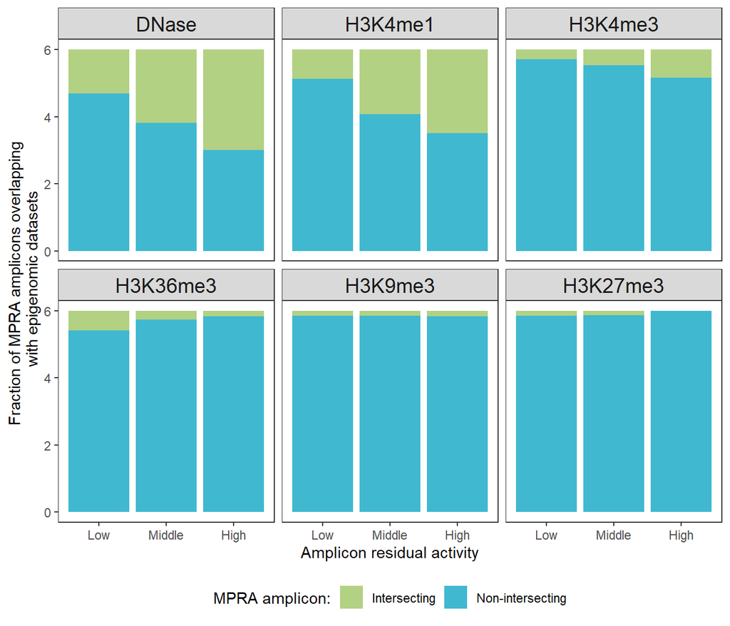

```r
# Only at q < 0.05 roadmap peak
df3_m <- dplyr::filter(df2_m, Epi_peak_q_value == 0.05)

df3_m$variable <- ifelse(df3_m$variable == "Fraction_intersecting", "Intersecting", "Non-intersecting")

fill <- c("#b2d183", "#40b8d0")

Fig_2C <- ggplot(df3_m, aes(fill = variable, y=value, x=Condition)) +
    geom_bar(position="stack", stat="identity")+
    theme_bw()+
    labs(x = "Amplicon residual activity",
         y = "Fraction of MPRA amplicons overlapping \n with epigenomic datasets")+
    labs(fill = "MPRA amplicon:")+
    facet_wrap(~Epi_mark)+
    scale_fill_manual(values=fill)+
    theme(panel.grid.major = element_blank(), panel.grid.minor = element_blank())+
    theme(strip.text.x = element_text(size = 14))+
    theme(legend.position="bottom")

Fig_2C
```

### 8.5.2 Enrichment P values

```r
epi_p_table <- distinct(filter(df_m, P_values_sampling < 0.1, Epi_peak_q_value == 0.05)[,c("Condition", "Epi_mark", "Epi_peak_q_value", "Fraction_intersecting", "P_values_sampling", "Significance")])

knitr::kable(arrange(epi_p_table, Epi_mark))
```

| Condition | Epi_mark | Epi_peak_q_value | Fraction_intersecting | P_values_sampling | Significance |
| --- | --- | --- | --- | --- | --- |
| High | DNase | 0.05 | 0.5000000 | 0.0333263 | P < 0.05 |
| Low | DNase | 0.05 | 0.2195122 | 0.0208687 | P < 0.05 |
| High | H3K4me1 | 0.05 | 0.4166667 | 0.0697773 | Non-significant |
| Low | H3K4me1 | 0.05 | 0.1463415 | 0.0077358 | P < 0.01 |
| High | H3K4me3 | 0.05 | 0.1388889 | 0.0905331 | Non-significant |

# 9. Values reported in the text

```r
sum(data.all$Maxi_counts > 200)
```

```
## [1] 345
```

“We generated an MPRA library consisting of 345 candidate human DNA sequences for testing, each ~900 bp in size, to assess functional enhancer activity in vivo in early postnatal mouse brain.”

```r
min_count = 200
n_of_genomic_AAV <- sum(rowSums(data.all[,c("L1_DNA_count", "L2_DNA_count", "L3_DNA_count", "L4_DNA_count")]>min_count) >=4)

n_of_genomic_AAV
```

```
## [1] 321
```

“We observed strong correlation between amplicon read counts in the pooled previral plasmid library (“Library”) and genomic AAV DNA (“DNA”) collected from each injected P7 brain (Figure 1B), with 321 /345 (93%) detected in the pooled previral library with >200 aligned reads present in all four DNA replicates."

```r
sum(data.predict$training)
```

```
## [1] 248
```

“Then, we used the middle 80% of amplicons (N = 248) ranked by RNA/DNA ratio (Supplemental Figure 4B) to build a linear model to account for background MPRA RNA based on amplicon representation and GC content (Supplemental Figure 4C-F).”

```r
sum(data.predict$Pvalue < 0.05)
```

```
## [1] 36
```

```r
sum(data.predict$FDR < 0.05)
```

```
## [1] 2
```

```r
sum(data.predict$Pvalue < 0.05 & data.predict$Residuals_Z_scaled_to_lm > 0)
```

```
## [1] 36
```

```r
sum(data.predict$FDR < 0.05 & data.predict$Residuals_Z_scaled_to_lm > 0)
```

```
## [1] 2
```

```r
sum(data.predict$Pvalue < 0.05 & data.predict$Residuals_Z_scaled_to_lm < 0)
```

```
## [1] 0
```

```r
sum(data.predict$FDR < 0.05 & data.predict$Residuals_Z_scaled_to_lm < 0)
```

```
## [1] 0
```

```r
sum(data.predict$MeanRatio > 1.5 & data.predict$MSD > 0)
```

```
## [1] 71
```

We found that 71 amplicons were considered active using the criteria RNA/DNA ratio > 1.5 including amplicons with mean greater than standard deviation.

```r
active_amp_by_lm <- data.predict$Pvalue < 0.05 & data.predict$Residuals_Z_scaled_to_lm > 0
active_amp_by_ratio <- data.predict$MeanRatio > 1.5

# It's more intuitive to run this on amp names instead of Booleans
active_amp_by_lm <- data.predict$Amp_name[active_amp_by_lm]  # 36
active_amp_by_ratio <- data.predict$Amp_name[active_amp_by_ratio]  #99

setdiff(active_amp_by_lm, active_amp_by_ratio) # "331_GWAS" - is the exception
```

```
## [1] "331_GWAS"
```

```r
#setdiff(active_amp_by_ratio, active_amp_by_lm)

# Let's investigate
df <- filter(data.predict, Amp_name %in% c(active_amp_by_lm, active_amp_by_ratio))
filter(df, Amp_name == "331_GWAS")[, c("Amp_name", "MSD", "MeanRatio_MoM", "MeanRatio", "Pvalue", "FDR")]
```

```
##          Amp_name        MSD MeanRatio_MoM MeanRatio     Pvalue       FDR
## 331_GWAS 331_GWAS -0.1362628      1.327962  1.406156 0.03432937 0.3986725
```

```r
# "331_GWAS" has negative MSD


# There are actually 35/36 amplicons identified as active using both approaches

round(35/36, digits = 2)
```

```
## [1] 0.97
```

35 out of 36 amplicons identified using model residuals were also active in the ratiometric comparison.

```r
sum(data.predict$Pvalue < 0.05 & data.predict$Residuals_Z_scaled_to_lm > 0)
```

```
## [1] 36
```

```r
sum(data.predict$Pvalue < 0.05 &
      data.predict$Residuals_Z_scaled_to_lm > 0 &
      data.predict$MSD > 1.5)
```

```
## [1] 18
```

```r
#data.predict$Amp_name[data.predict$Pvalue < 0.05 &
#      data.predict$Residuals_Z_scaled_to_lm > 0 &
#      data.predict$MSD > 1.5]
```

Among 36 positive amplicons with significant regression residual activity (P < 0.05), 18 (50%) had mean ratio – 1 s.d. > 1.5, representing the amplicons with the strongest MPRA-defined enhancer activity (Figure 2B).

# 10. R sessionInfo()

```r
library(pander)

pander(sessionInfo())
```

**R version 4.0.2 (2020-06-22)**

**Platform:** x86_64-w64-mingw32/x64 (64-bit)

**locale:** *LC_COLLATE=English_United States.1252*, *LC_CTYPE=English_United States.1252*, *LC_MONETARY=English_United States.1252*, *LC_NUMERIC=C* and *LC_TIME=English_United States.1252*

**attached base packages:** *parallel*, *stats4*, *stats*, *graphics*, *grDevices*, *utils*, *datasets*, *methods* and *base*

**other attached packages:** *pander(v.0.6.3)*, *R.utils(v.2.10.1)*, *R.oo(v.1.24.0)*, *R.methodsS3(v.1.8.1)*, *XML(v.3.99-0.3)*, *RCurl(v.1.98-1.2)*, *gdtools(v.0.2.2)*, *gridExtra(v.2.3)*, *GenomicRanges(v.1.40.0)*, *GenomeInfoDb(v.1.24.2)*, *IRanges(v.2.22.2)*, *S4Vectors(v.0.26.1)*, *BiocGenerics(v.0.34.0)*, *DT(v.0.16)*, *plotly(v.4.9.2.2)*, *RColorBrewer(v.1.1-2)*, *ggpmisc(v.0.3.7)*, *data.table(v.1.12.8)*, *reshape2(v.1.4.4)*, *genefilter(v.1.70.0)*, *GGally(v.2.0.0)*, *forcats(v.0.5.0)*, *stringr(v.1.4.0)*, *dplyr(v.1.0.0)*, *purrr(v.0.3.4)*, *readr(v.1.3.1)*, *tidyr(v.1.1.0)*, *tibble(v.3.0.1)*, *ggplot2(v.3.3.2)* and *tidyverse(v.1.3.0)*

**loaded via a namespace (and not attached):** *nlme(v.3.1-148)*, *bitops(v.1.0-6)*, *fs(v.1.4.2)*, *lubridate(v.1.7.9)*, *bit64(v.4.0.5)*, *httr(v.1.4.2)*, *tools(v.4.0.2)*, *backports(v.1.1.7)*, *R6(v.2.5.0)*, *mgcv(v.1.8-31)*, *DBI(v.1.1.0)*, *lazyeval(v.0.2.2)*, *colorspace(v.1.4-1)*, *withr(v.2.3.0)*, *tidyselect(v.1.1.0)*, *bit(v.4.0.4)*, *compiler(v.4.0.2)*, *cli(v.2.2.0)*, *rvest(v.0.3.6)*, *Biobase(v.2.48.0)*, *xml2(v.1.3.2)*, *labeling(v.0.4.2)*, *scales(v.1.1.1)*, *systemfonts(v.0.3.2)*, *digest(v.0.6.25)*, *svglite(v.1.2.3.2)*, *rmarkdown(v.2.6)*, *XVector(v.0.28.0)*, *pkgconfig(v.2.0.3)*, *htmltools(v.0.5.0)*, *highr(v.0.8)*, *dbplyr(v.2.0.0)*, *htmlwidgets(v.1.5.3)*, *rlang(v.0.4.9)*, *readxl(v.1.3.1)*, *rstudioapi(v.0.13)*, *RSQLite(v.2.2.1)*, *farver(v.2.0.3)*, *generics(v.0.1.0)*, *jsonlite(v.1.7.2)*, *crosstalk(v.1.1.0.1)*, *magrittr(v.2.0.1)*, *polynom(v.1.4-0)*, *GenomeInfoDbData(v.1.2.3)*, *Matrix(v.1.2-18)*, *Rcpp(v.1.0.6)*, *munsell(v.0.5.0)*, *fansi(v.0.4.1)*, *lifecycle(v.0.2.0)*, *stringi(v.1.4.6)*, *yaml(v.2.2.1)*, *zlibbioc(v.1.34.0)*, *plyr(v.1.8.6)*, *grid(v.4.0.2)*, *blob(v.1.2.1)*, *crayon(v.1.3.4)*, *lattice(v.0.20-41)*, *haven(v.2.3.1)*, *splines(v.4.0.2)*, *annotate(v.1.66.0)*, *hms(v.0.5.3)*, *knitr(v.1.30)*, *pillar(v.1.4.7)*, *reprex(v.0.3.0)*, *glue(v.1.4.1)*, *evaluate(v.0.14)*, *modelr(v.0.1.8)*, *vctrs(v.0.3.0)*, *cellranger(v.1.1.0)*, *gtable(v.0.3.0)*, *reshape(v.0.8.8)*, *assertthat(v.0.2.1)*, *xfun(v.0.15)*, *xtable(v.1.8-4)*, *broom(v.0.7.3)*, *survival(v.3.1-12)*, *viridisLite(v.0.3.0)*, *AnnotationDbi(v.1.50.3)*, *memoise(v.1.1.0)* and *ellipsis(v.0.3.1)*